# Trabalho_Extração, Grupo8

# 1 **Carregamento dos packages e dos datasets utilizados**

```r
library(MultiAssayExperiment)
library(clusterProfiler)
library(AnnotationDbi)
library(ReactomePA)
library(DESeq2)
library(edgeR)
library(gplots)
library(limma)
library(Glimma)
library('org.Hs.eg.db')
library('RColorBrewer')
library(tidyverse)
library(hgu95av2.db)
library(GOstats)
library(caret)
library(ggnewscale)
library(summarytools)
library(genefilter)
library(factoextra)
library(scatterplot3d)
library(ggfortify)
library(dendextend)

CCLE_gene = read.csv('CCLE_gene_cn.csv')
CCLE_expression = read.csv('CCLE_expression.csv')
Achilles_gene = read.csv('Achilles_gene_effect.csv')
Sample_Info = read.csv('sample_info.csv')
dim(Sample_Info)
```

```
## [1] 1811   26
```

```r
dim(CCLE_expression)
```

```
## [1]  1376 19178
```

```r
dim(CCLE_gene)
```

```
## [1]  1740 27563
```

```r
dim(Achilles_gene)
```

```
## [1]   808 18120
```

# 2 **Explicação dos dados, relevância e origem**

## 2.1 Sample_Info

Dataset contendo as informações genéricas sobre as linhas celulares. Cada linha neste dataset representa uma linhagem celular e ao longo das colunas os atributos associados mesmos. O conteúdo que pode ser encontrado nas colunas encontra-se discriminado na lista abaixo:

*DepMap_ID*: A nomenclatura de identificação (ID) da linha celular associado ao DepMap.

*Stripped_cell_name*: Nome da linha celular com caracteres alfa numéricos.

*CCLE_Name*: Nome para a linha celular utilizado pela Cancer Cell Line Encycopedia(CCLE).

*Alias*: Identificadores da linha celular adicional em lista.

*COSMIC_ID*: ID da linha celular associado à base de dados Cosmic cancer.

*Lineage, lineage_subtype, lineage_sub_subtype, lineage_molecular_subtype*: Classificação standard do tipo de cancro.

*Sex*: Sexo do dador de tecido.

*Source*: Fonte da linha celular utilizada pelo DepMap.

*Achilles_n_replicates*: Número de réplicas utilizadas em Achiles CRISPR screen passadas pelo Quality Control (QC).

*Cell_line_NNMD*: Diferenças nas médias dos controles positivos e negativos normalizados pelo desvio padrão da distribuição do controle negativo.

*Culture_type*: MÉtodo de crescimento da linha celular (Aderente, Suspensão, Aderente e Suspensão misto, 3D ou aderente com revestimento de lâmina).

*Culture_Medium*: Meio utilizado no crescimento da linha celular.

*Cas9_activity*: Percentagem de células marcadas com Green Flourescent Protein (GFP) positivas entre os dias 12-14 para a presença de Cas9, medido pelo Citomátros de Fluxo (FAC).

*RRID*: Identificador de pesquisa para Cellosauros research.

*Sample_collection_site*: Indicações sobre a amostra de tecido, ou seja, se o tecido foi retirado de um carcinoma Primário ou de uma metástase resultante de um carcinoma Primário.

*Disease*: Categoria geral da linhagem cancerígena.

*Disease_subtype*: Nome específico do carcinoma.

*Age*: Idade do dador de tecido.

*Sanger_Model_ID*: ID do passaporte do modelo celular associado ao instituto Sanger.

*Additional_info*: Mais informações sobre alterações nas linhas celulares e a sua resistência a medicamentos.

Este possui **1811 linhas celulares** e **26 colunas** de informações genéricas.

## 2.2 CCLE_Expression

CCLE_Expression é um dataset obtido pela Cancer Cell Line Encyclopedia(CCLE) sendo a CCLE um projeto responsável por realizar a caracterização genética e farmacológica de modelos de cancro humano, para desenvolver análises computacionais integradas que efetuam a ligação entre vulnerabilidades farmacológicas a padrões genómicos. Este dataset contem dados de expressão genética de RNAseq TPM(Transcripts per million/ É um método de normalização para o RNAseq), para apenas genes codificadores de proteína usando o RSEM(Quantificador de transcritos). Os dados foram transformados através da logaritmação por 2. A linha contém o ID da linha celular associado ao DepMap, já¡ nas colunas a identificação dos genes (Symbol & Entrez ID).

Este possui **1376 linhas celulares**(linhas) e e dados de expressão genética de **19178 genes codificadores de proteína**(colunas).

## 2.3 CCLE_gene

CCLE_gene É um dataset obtido pela CCLE. Este dataset contem informação do *Gene Level Copynumber*, É gerado pelo mapeamento dos genes contra linhas celulares. Sendo o *copy number* o número de repetições do gene ao longo do genoma da linha celular. Os resultados encontram-se transformados utilizando a logaritmação por 2, iniciando numa pseudo-contagem de 1, de modo a conter apenas números positivos.

Este possui **1740 linhas celulares**(linhas) e **27563 genes mapeados**(colunas).

## 2.4 Achilles_gene

Este dataset É estabelece uma relação entre as linhas celulares (presentes nas linhas) e dados correspondentes aos genes (ID dos mesmos nas colunas).O dados associados a cada gene na linhas celulares retém a informação pós CERES-CERES. O Ceres calcula a probabilidade de um gene ser essencial para a homeostasia e sobrevivência da linha celular. O valor associado ao gene é quanto mais negativo, maior É a sua importância para a sobrevivência da linha celular. Como tratamento final estes valores foram alterados de modo que a média dos genes essenciais seja de -1 e dos que não são essenciais de 0. Este possui **808 linhas celulares**(linhas) e **18120 genes mapeados**(colunas).

# 3 **Preparação dos Dataset**

## 3.1 Edição dos datasets

```r
#Alteração do nome da coluna associado ao DepMap ID das linhas celulares para a mesma nomenclatura
names(Achilles_gene)[names(Achilles_gene) == "X"] <- "DepMap_ID"
rownames(Achilles_gene)= Achilles_gene$DepMap_ID
names(CCLE_expression)[names(CCLE_expression) == "X"] <- "DepMap_ID"
rownames(CCLE_expression)= CCLE_expression$DepMap_ID
names(CCLE_gene)[names(CCLE_gene) == "X"] <- "DepMap_ID"
rownames(CCLE_gene)= CCLE_gene$DepMap_ID
rownames(Sample_Info)= Sample_Info$DepMap_ID

Achilles_gene = Achilles_gene[,-c(1)]
CCLE_expression = CCLE_expression[,-c(1)]
CCLE_gene = CCLE_gene[,-c(1)]


#remover coluna respetivamente aos resultados
Sample_Info = Sample_Info[,-c(1,6,15,21,22,26)]
Sample_Info= Sample_Info[which(Sample_Info$cas9_activity>0.70),]
Sample_Info=Sample_Info[which(Sample_Info$primary_or_metastasis!=""),]
Achilles_gene = na.exclude(Achilles_gene)
```

## 3.2 Filtração entre datasets

```r
#flat patterns


exp = as.matrix(CCLE_expression)
sds = colSds(exp)
m = median(sds)
CCLE_expression = CCLE_expression[,sds >= 2*median(sds)]

#Geração de dataset resultantes dos ficheiros iniciais através do cruzamento de ficheiros
Sub_sample_info <- Sample_Info %>% filter(rownames(Sample_Info) %in% rownames(Achilles_gene))
Sub_CRISPR <- Achilles_gene %>% filter(rownames(Achilles_gene) %in% rownames(Sub_sample_info))
Sub_CCLE_gene <- CCLE_gene %>% filter(rownames(CCLE_gene) %in% rownames(Sub_CRISPR))
Sub_CCLE_expression <- CCLE_expression %>% filter(rownames(CCLE_expression) %in% rownames(Sub_CCLE_gene))
Sub_sample_info <- Sub_sample_info %>% filter(rownames(Sub_sample_info) %in% rownames(Sub_CCLE_expression))
Sub_CRISPR <- Sub_CRISPR %>% filter(rownames(Sub_CRISPR) %in% rownames(Sub_CCLE_expression))
Sub_CCLE_gene <- Sub_CCLE_gene %>% filter(rownames(Sub_CCLE_gene) %in% rownames(Sub_CCLE_expression))

#ordenadar todos os datatsets pela mesma ordem em rownames
index = match(rownames(Sub_sample_info),rownames(Sub_CRISPR))
Sub_CRISPR = Sub_CRISPR[c(index),]
index = match(rownames(Sub_sample_info),rownames(Sub_CCLE_gene))
Sub_CCLE_gene = Sub_CCLE_gene[c(index),]
index = match(rownames(Sub_sample_info),rownames(Sub_CCLE_expression))
Sub_CCLE_expression = Sub_CCLE_expression[c(index),]

dim(Sub_sample_info)
```

```
## [1] 605  20
```

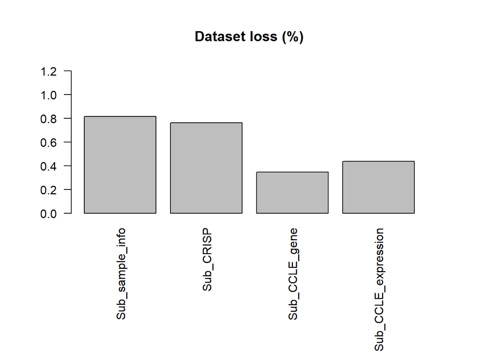

```r
Lost= c(length(rownames(Sub_sample_info))/length(rownames(Sample_Info)),
        length(rownames(Sub_CRISPR))/length(rownames(Achilles_gene)),
        length(rownames(Sub_CCLE_gene))/length(rownames(CCLE_gene)),
        length(rownames(Sub_CCLE_expression))/length(rownames(CCLE_expression)))
par(mar=c(10,5,5,5))
barplot(Lost, ylim=c(0,1.2),las=2, main = 'Dataset loss (%)', names.arg = c('Sub_sample_info','Sub_CRISP', 'Sub_CCLE_gene','Sub_CCLE_expression'))
```

De modo a manter tambem em comum os genes entre os vários datasets foram tambem cruzados para conterem todos os mesmos genes, semelhantemente ao anteriormente realizado as colunas(genes) foram tambem ordenadas da mesma forma para homogeneizar os vários datasets.

```r
#Intersetar os datasets para ter o mesmo numero de genes
SubSG_CCLE_Exp = Sub_CCLE_expression[, intersect(colnames(Sub_CCLE_expression), colnames(Sub_CCLE_gene))]
SubSG_CCLE_genes = Sub_CCLE_gene[, intersect(colnames(Sub_CCLE_gene), colnames(Sub_CCLE_expression))]
SubSG_CCLE_Exp = SubSG_CCLE_Exp[, intersect(colnames(SubSG_CCLE_Exp),colnames(Sub_CRISPR))]
SubSG_CCLE_genes = SubSG_CCLE_genes[, intersect(colnames(SubSG_CCLE_genes), colnames(Sub_CRISPR))]
SubSG_CRISPR = Sub_CRISPR[, intersect(colnames(Sub_CRISPR), colnames(SubSG_CCLE_genes))]
SubSG_CRISPR = SubSG_CRISPR[, intersect(colnames(SubSG_CRISPR), colnames(SubSG_CCLE_genes))]

index = match(colnames(SubSG_CCLE_Exp),colnames(SubSG_CCLE_genes))
SubSG_CCLE_genes = SubSG_CCLE_genes[,c(index)]
index = match(colnames(SubSG_CCLE_Exp),colnames(SubSG_CRISPR))
SubSG_CRISPR = SubSG_CRISPR[,c(index)]


dim(SubSG_CCLE_genes)
```

```
## [1]  605 2062
```

No total são mantidos ** 2062 genes**, seguindo apenas estes para as restantes fases.

## 3.3 Estrutura final dos datasets

```r
sum(is.na(Sub_sample_info))
```

```
## [1] 147
```

```r
sum(is.na(Sub_CCLE_gene))
```

```
## [1] 0
```

```r
sum(is.na(Sub_CCLE_expression))
```

```
## [1] 0
```

```r
sum(is.na(Sub_CRISPR))
```

```
## [1] 0
```

```r
str(Sub_sample_info)
```

```
## 'data.frame':    605 obs. of  20 variables:
##  $ cell_line_name         : chr  "LS513" "C2BBe1" "253J" "HCC827" ...
##  $ stripped_cell_line_name: chr  "LS513" "C2BBE1" "253J" "HCC827" ...
##  $ CCLE_Name              : chr  "LS513_LARGE_INTESTINE" "C2BBE1_LARGE_INTESTINE" "253J_URINARY_TRACT" "HCC827_LUNG" ...
##  $ Alias                  : chr  "" "" "" "" ...
##  $ sex                    : chr  "Male" "Male" "Male" "Female" ...
##  $ source                 : chr  "ATCC" "ATCC" "KCLB" "ATCC" ...
##  $ Achilles_n_replicates  : num  2 3 1 3 2 2 2 2 2 2 ...
##  $ cell_line_NNMD         : num  -2.59 -4.14 -3.18 -4.24 -5.32 ...
##  $ culture_type           : chr  "Adherent" "Adherent" "" "Adherent" ...
##  $ culture_medium         : chr  "RPMI + 10% FBS" "DMEM + 10% FBS + Glutamine + Insulin-Transferrin-Selenium" "DMEM + 10% FBS" "RPMI + 10% FBS" ...
##  $ cas9_activity          : num  47.7 94.2 89 87.3 92 84.9 47.2 72.9 65.2 65 ...
##  $ RRID                   : chr  "CVCL_1386" "CVCL_1096" "CVCL_7935" "CVCL_2063" ...
##  $ sample_collection_site : chr  "large_intestine" "Colon" "lymph_node" "lung" ...
##  $ primary_or_metastasis  : chr  "Primary" "Primary" "Metastasis" "Primary" ...
##  $ primary_disease        : chr  "Colon/Colorectal Cancer" "Colon/Colorectal Cancer" "Bladder Cancer" "Lung Cancer" ...
##  $ Subtype                : chr  "Adenocarcinoma" "Adenocarcinoma" "Carcinoma" "Non-Small Cell Lung Cancer (NSCLC), Adenocarcinoma" ...
##  $ age                    : num  63 72 53 39 60 56 44 43 81 69 ...
##  $ lineage                : chr  "colorectal" "colorectal" "urinary_tract" "lung" ...
##  $ lineage_subtype        : chr  "colorectal_adenocarcinoma" "colorectal_adenocarcinoma" "bladder_carcinoma" "NSCLC" ...
##  $ lineage_sub_subtype    : chr  "" "" "" "NSCLC_adenocarcinoma" ...
```

```r
str(Sub_CRISPR)
```

```
## 'data.frame':    605 obs. of  18119 variables:
##  $ A1BG..1.             : num  0.0662 0.0979 0.2702 0.0154 0.0628 ...
##  $ A1CF..29974.         : num  0.07385 0.000361 0.072105 0.17313 0.038242 ...
##  $ A2M..2.              : num  -0.0659 -0.0558 0.0146 0.1043 -0.0308 ...
##  $ A2ML1..144568.       : num  0.156 0.0462 0.4332 0.3058 0.2107 ...
##  $ A3GALT2..127550.     : num  0.101 0.0631 -0.0303 0.0582 -0.0657 ...
##  $ A4GALT..53947.       : num  0.141 -0.0489 -0.2391 -0.19 -0.0797 ...
##  $ A4GNT..51146.        : num  0.0664 0.0709 0.0979 0.3217 0.0654 ...
##  $ AAAS..8086.          : num  -0.473 -0.641 -0.42 -0.493 -0.463 ...
##  $ AACS..65985.         : num  -0.00881 0.14833 0.13864 0.08412 0.04038 ...
##  $ AADAC..13.           : num  0.2934 0.0562 0.1063 0.3343 0.2712 ...
##  $ AADACL2..344752.     : num  0.1792 0.0602 0.1342 0.1668 0.2139 ...
##  $ AADACL3..126767.     : num  0.0325 -0.2601 -0.0902 -0.1613 -0.0283 ...
##  $ AADACL4..343066.     : num  0.0357 -0.1194 -0.084 -0.0337 0.0539 ...
##  $ AADAT..51166.        : num  -0.0258 0.0851 0.0701 -0.0395 0.1254 ...
```

[output cut: 88 more lines]

```r
str(Sub_CCLE_expression)
```

```
## 'data.frame':    605 obs. of  2173 variables:
##  $ TSPAN6..7105.          : num  4.03 6.5 4.56 5.8 5.52 ...
##  $ CFH..3075.             : num  0.0144 0.0426 0.3785 2.7506 2.067 ...
##  $ FUCA2..2519.           : num  5.54 7.12 5.53 6.22 5.42 ...
##  $ SEMA3F..6405.          : num  1.406 2.709 3.614 0.333 4.975 ...
##  $ CD99..4267.            : num  7.38 8.21 5.75 6.01 5.24 ...
##  $ TMEM176A..55365.       : num  2.8777 4.1457 0 0.0144 0.6135 ...
##  $ KLHL13..90293.         : num  0.0144 3.2403 6.1629 0.6599 3.6724 ...
##  $ ICA1..3382.            : num  6.32 4.89 1.4 4.36 4.58 ...
##  $ DBNDD1..79007.         : num  3.71 5.85 2.59 5.39 4.1 ...
##  $ TFPI..7035.            : num  0.0566 5.3806 7.6838 6.0166 0.5558 ...
##  $ SLC7A2..6542.          : num  0.0144 4.2087 0.0566 1.8875 2.8012 ...
##  $ PLXND1..23129.         : num  1.31 4.73 3.19 2.21 5.86 ...
##  $ CD38..952.             : num  0.0144 0.0286 0.0704 0.0566 0.3219 ...
##  $ HSPB6..126393.         : num  0.0426 0.1375 0.5945 0.2016 0.2388 ...
```

[output cut: 86 more lines]

```r
str(Sub_CCLE_gene)
```

```
## 'data.frame':    605 obs. of  27562 variables:
##  $ DDX11L1..100287102.                  : num  0.965 0.824 0.821 0.808 1.412 ...
##  $ WASH7P..653635.                      : num  0.965 0.824 0.821 0.808 1.412 ...
##  $ FAM138A..645520.                     : num  0.965 0.824 0.821 0.808 1.412 ...
##  $ OR4F5..79501.                        : num  0.965 0.824 0.821 0.808 1.412 ...
##  $ LOC729737..729737.                   : num  0.965 0.824 0.821 0.808 1.412 ...
##  $ LOC102725121..102725121.             : num  0.965 0.824 0.821 0.808 1.412 ...
##  $ LOC101928626..101928626.             : num  0.965 0.824 0.821 0.808 1.412 ...
##  $ LOC100133331..100133331.             : num  0.965 0.824 0.821 0.808 1.412 ...
##  $ LOC100288069..100288069.             : num  0.965 0.824 0.821 0.808 1.412 ...
##  $ FAM87B..400728.                      : num  0.965 0.824 0.821 0.808 1.412 ...
##  $ LINC00115..79854.                    : num  0.965 0.824 0.821 0.808 1.412 ...
##  $ LINC01128..643837.                   : num  0.965 0.824 0.821 0.808 1.412 ...
##  $ FAM41C..284593.                      : num  0.965 0.824 0.821 0.808 1.412 ...
##  $ LOC100130417..100130417.             : num  0.965 0.824 0.821 0.808 1.412 ...
```

[output cut: 86 more lines]

No final apenas o dataset **Sub_sample_info** mantém 147 valores omissos, estando associado a colunas não relevantes para o estudo.

# 4 **Análise exploratória**

## 4.1 Análise generalizada

A analise exploratória foi realizada com subgrupo **Sub_sample_info** gerado a partir do dataset **Sample_Info**. Considerado que o objetivo de estudo é estabelecer ligações entre os diferentes datasets, deste modo apenas usadas linhagens celulares comuns a todos os datasets.

```r
view(dfSummary(Sub_sample_info, style = 'grid', graph.magnif = 0.75,tmp.img.dir = "/tmp"))
```

```
## Switching method to 'browser'
```

```
## Output file written: C:\Users\josep\AppData\Local\Temp\RtmpstzSg0\file26906f3cbe9.html
```

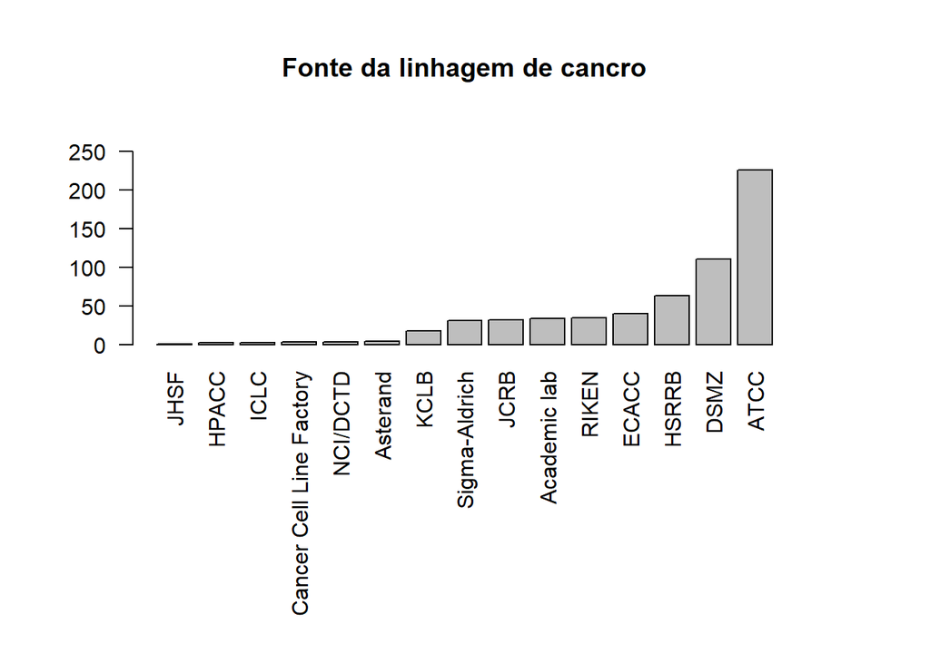

```r
#Grafico relativo à origem do cancro
source = sort(table(Sub_sample_info$source))
par(mar=c(12,5,5,5))
barplot(source ,main='Fonte da linhagem de cancro',ylim = c(0,275),col = 'gray',las=2)
```

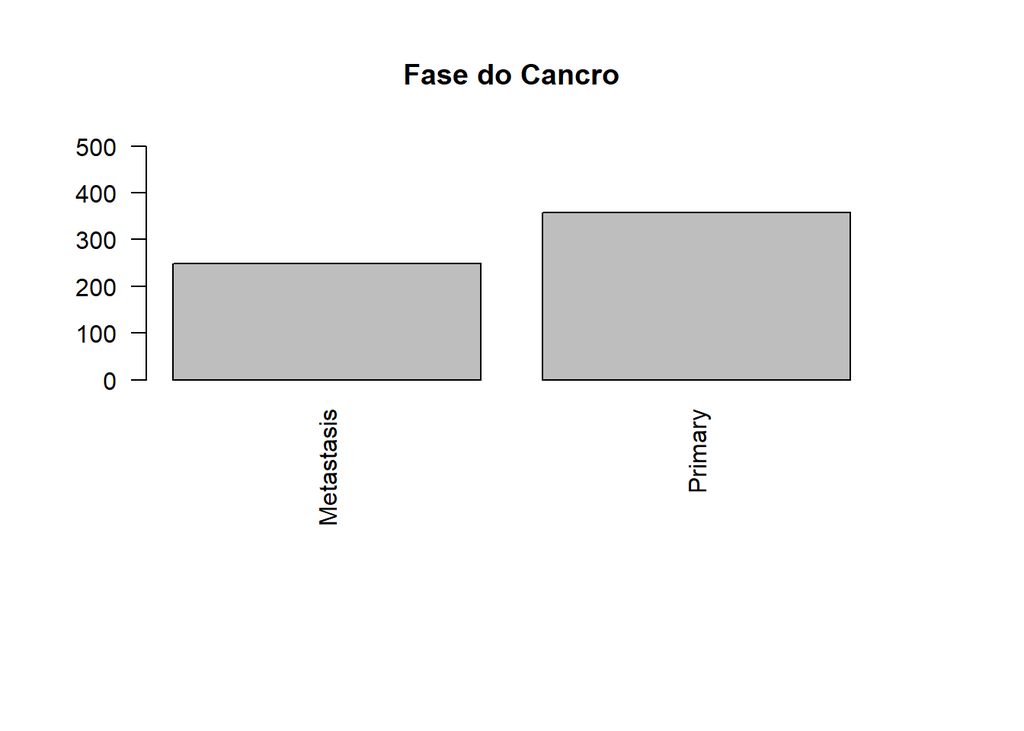

```r
#Distribuição dos tipos de cancro
cancer = table(Sub_sample_info$primary_or_metastasis)
barplot(cancer,ylim = c(0,500) ,main='Fase do Cancro',col = 'gray',las=2)
```

No barplot de **Fase do Cancro** é possivel verificar a existência de uma maior quantidade de carcinomas *‘Primary’* do que carcinomas do género *‘Mestastasis’*.

## 4.2 Análise de informação do paciente vs Fase do carcinoma

Considerando que a característica dos Pacientes tem influência sobre a potencialidade de surgimento de células cancerígenas. Achamos interessante estudar a relação entre a fase em que o cancro foi isolado com as características do Paciente.

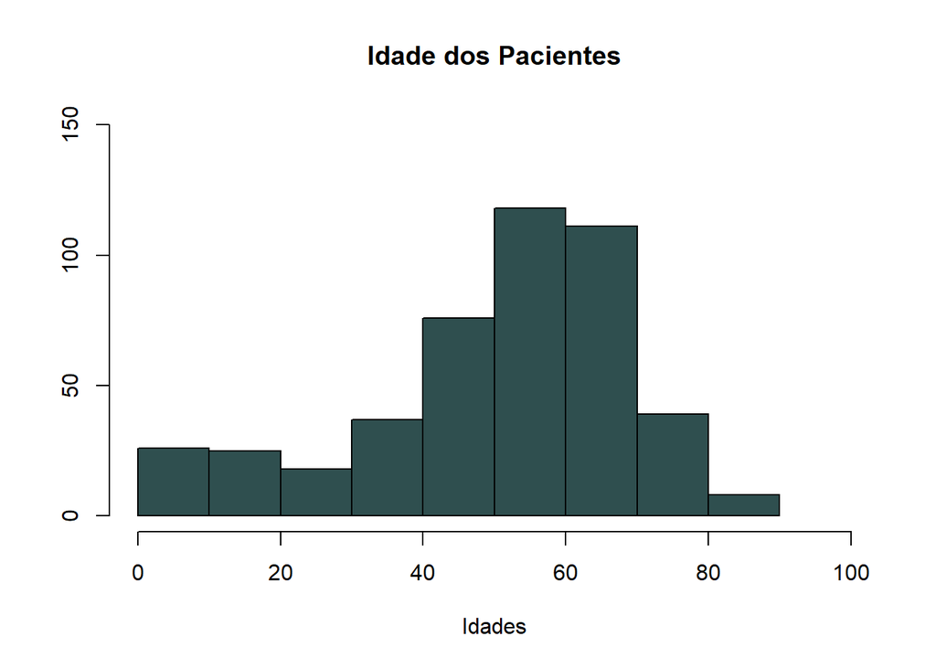

```r
#Histograma referente à idade dos pacientes
idades=which(Sub_sample_info$age != "NA")
hist(Sub_sample_info$age[idades], breaks = 10, col="darkslategray",
     ylim=c(0,150), xlim = c(0,100), main = 'Idade dos Pacientes', xlab = 'Idades', ylab ='')
```

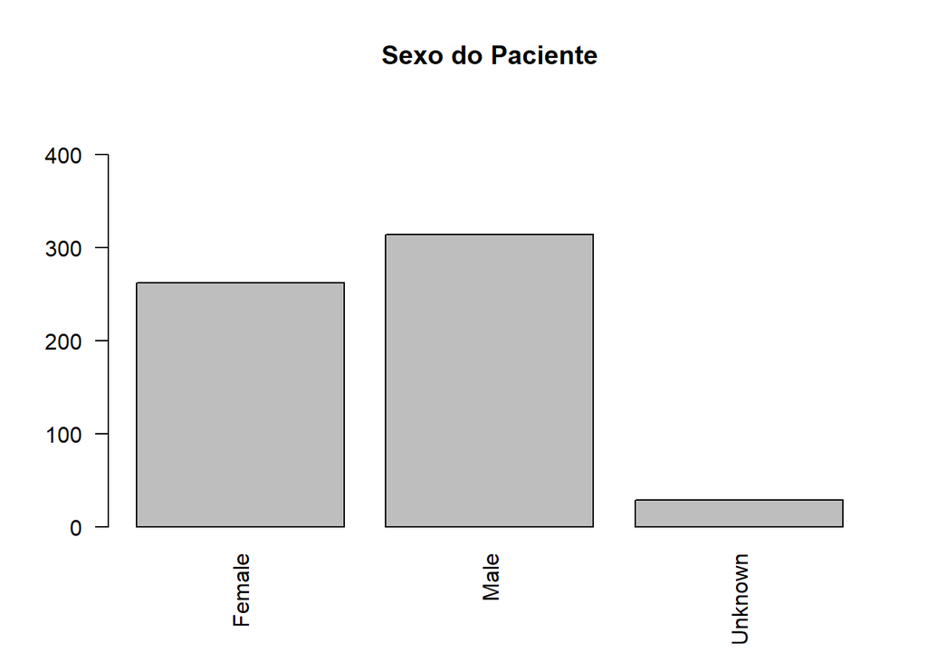

```r
#Distribuição do Sexo dos Pacientes
sexo = table(Sub_sample_info$sex)
barplot(sexo, ylim=c(0,450), las=2, main = 'Sexo do Paciente')
```

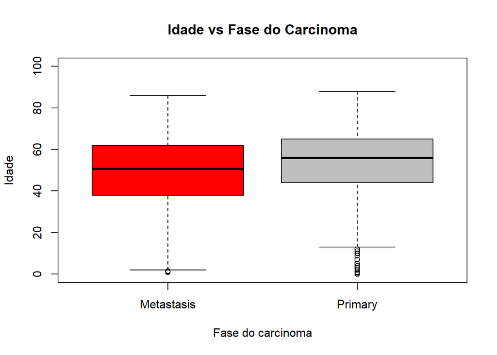

```r
#Boxplot de interação do tipo de Cancro com as idades do Paciente
boxplot(Sub_sample_info$age ~ Sub_sample_info$primary_or_metastasis, ylim=c(0,100), xlab = 'Fase do carcinoma', ylab='Idade', col = c('red','grey','darkgreen'),  main = 'Idade vs Fase do Carcinoma')
```

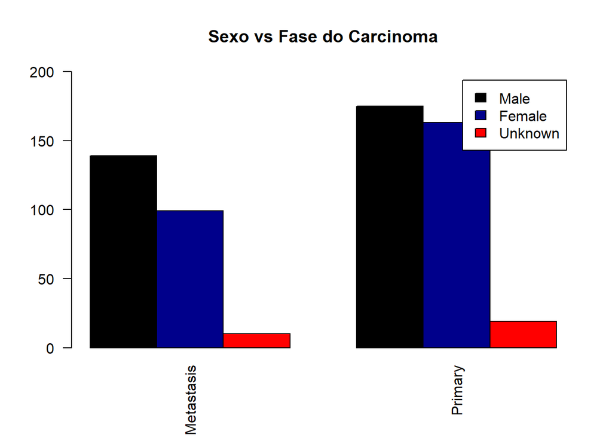

```r
#Incidencia do tipo de cancro consoante o sexo
M = which(Sub_sample_info$sex=='Male')
F = which(Sub_sample_info$sex=='Female')
U = which(Sub_sample_info$sex=='Unknown')
barplot(rbind(table(Sub_sample_info$primary_or_metastasis[M]),table(Sub_sample_info$primary_or_metastasis[F]),table(Sub_sample_info$primary_or_metastasis[U])),las=2,beside = T,col = c('black','darkblue','red'),legend = c('Male','Female','Unknown'),ylim=c(0,200),  main = 'Sexo vs Fase do Carcinoma')
```

```r
#Anova e Tukey test para análise das variâncias para a idade e tipo de cancro
anva = aov(Sub_sample_info$age ~ Sub_sample_info$primary_or_metastasis)
summary(anva)
```

```
##                                        Df Sum Sq Mean Sq F value Pr(>F)
## Sub_sample_info$primary_or_metastasis   1   2472  2471.8   6.683   0.01 *
## Residuals                             456 168651   369.8
## ---
## Signif. codes:  0 '***' 0.001 '**' 0.01 '*' 0.05 '.' 0.1 ' ' 1
## 147 observations deleted due to missingness
```

```r
TukeyHSD(anva)
```

```
##   Tukey multiple comparisons of means
##     95% family-wise confidence level
##
## Fit: aov(formula = Sub_sample_info$age ~ Sub_sample_info$primary_or_metastasis)
##
## $`Sub_sample_info$primary_or_metastasis`
##                        diff      lwr      upr     p adj
## Primary-Metastasis 4.730361 1.134468 8.326253 0.0100424
```

```r
#Anova e Tukey test para análise das variâncias para a sexo e tipo de cancro
g_sex = unique(Sub_sample_info$sex)
g_PM = unique(Sub_sample_info$primary_or_metastasis)
sex = as.numeric(factor(Sub_sample_info$sex, levels=g_sex))
PM = as.numeric(factor(Sub_sample_info$primary_or_metastasis, levels=g_PM))

anvf1 = aov(sex ~ as.factor(PM))
summary(anvf1)
```

```
##                Df Sum Sq Mean Sq F value Pr(>F)
## as.factor(PM)   1   1.01  1.0127    2.94 0.0869 .
## Residuals     603 207.73  0.3445
## ---
## Signif. codes:  0 '***' 0.001 '**' 0.01 '*' 0.05 '.' 0.1 ' ' 1
```

```r
TukeyHSD(anvf1)
```

```
##   Tukey multiple comparisons of means
##     95% family-wise confidence level
##
## Fit: aov(formula = sex ~ as.factor(PM))
##
## $`as.factor(PM)`
##           diff        lwr        upr     p adj
## 2-1 -0.0831865 -0.1784728 0.01209982 0.0869468
```

## 4.3 Estatística Univariada dos datasets.

De seguida foi gerado um loop para testar cada dataset para a sua normalidade segundo o teste de shapiro. Quando a normalidade era verificada, era realizado um teste anova sobre fatores. No entanto, quando não era verificado era realizado um teste de Kruskal-Wallis sobre fatores. Os fatores considerados foram a fase do carcinoma e a doença principal.

```r
normal = c()
n_normal = c()
normal_PM = c()
normal_lina = c()
n_normal_PM= c()
n_normal_lina= c()
N = 1
NN=1
for (i in 1:ncol(SubSG_CCLE_genes))
  {shat = shapiro.test(SubSG_CCLE_genes[,i])
  if (shat$p.value > 0.05)
    {normal[N]=i
    anv1 = aov(SubSG_CCLE_genes[,i] ~ Sub_sample_info$primary_or_metastasis, data=SubSG_CCLE_genes)
    anv2 = aov(SubSG_CCLE_genes[,i] ~ Sub_sample_info$primary_disease, data=SubSG_CCLE_genes)
    normal_PM[N] = na.exclude(summary(anv1)[[1]][["Pr(>F)"]])
    normal_lina[N] = na.exclude(summary(anv2)[[1]][["Pr(>F)"]])
    N = N+1}
  else
      {n_normal[NN]=i
      krustal1= kruskal.test(SubSG_CCLE_genes[,i] ~ Sub_sample_info$primary_or_metastasis, data= SubSG_CCLE_genes)
      krustal2= kruskal.test(SubSG_CCLE_genes[,i] ~ Sub_sample_info$primary_disease, data= SubSG_CCLE_genes)
      n_normal_PM[NN] = krustal1$p.value
      n_normal_lina[NN] = krustal2$p.value
      NN = NN +1}}

length(normal)
```

```
## [1] 0
```

```r
length(n_normal)
```

```
## [1] 2062
```

```r
colnames(SubSG_CCLE_genes[,normal])
```

```
## character(0)
```

```r
length(which(n_normal_PM < 0.05))
```

```
## [1] 367
```

```r
colnames(SubSG_CCLE_genes[,which(n_normal_PM < 0.05)])
```

```
##   [1] "TMEM176A..55365."   "DBNDD1..79007."     "TFPI..7035."
##   [4] "TSPOAP1..9256."     "ITGA3..3675."       "CX3CL1..6376."
##   [7] "CD79B..974."        "CYB561..1534."      "MRC2..9902."
##  [10] "GPRC5A..9052."      "CPS1..1373."        "TIMP2..7077."
##  [13] "CDH1..999."         "TNC..3371."         "KITLG..4254."
##  [16] "EPN3..55040."       "LTBP1..4052."       "ARHGEF5..7984."
##  [19] "CYBA..1535."        "PTPRN..5798."       "KCNH2..3757."
##  [22] "GNA15..2769."       "NCKAP1..10787."     "CDH3..1001."
##  [25] "GPC1..2817."        "ATP2C2..9914."      "NGFR..4804."
##  [28] "TLE2..7089."        "NGEF..25791."       "SP100..6672."
##  [31] "ST6GALNAC1..55808." "ST6GALNAC2..10610." "LMCD1..29995."
##  [34] "TRIB2..28951."      "CYBRD1..79901."     "SPEG..10290."
##  [37] "LLGL2..3993."       "DHRS9..10170."      "NTN4..59277."
##  [40] "ADD2..119."         "FOSL2..2355."       "CACNG4..27092."
##  [43] "STXBP2..6813."      "MAP2..4133."        "TNS1..7145."
```

[output cut: 108 more lines]

```r
length(which(n_normal_lina < 0.05))
```

```
## [1] 1883
```

```r
colnames(SubSG_CCLE_genes[,which(n_normal_lina < 0.05)])
```

```
##    [1] "TSPAN6..7105."       "CFH..3075."          "FUCA2..2519."
##    [4] "SEMA3F..6405."       "CD99..4267."         "TMEM176A..55365."
##    [7] "KLHL13..90293."      "ICA1..3382."         "TFPI..7035."
##   [10] "SLC7A2..6542."       "PLXND1..23129."      "PRKAR2B..5577."
##   [13] "TSPOAP1..9256."      "ITGAL..3683."        "ITGA3..3675."
##   [16] "TMEM98..26022."      "YBX2..51087."        "CX3CL1..6376."
##   [19] "BAIAP2L1..55971."    "ETV1..2115."         "SCIN..85477."
##   [22] "PNPLA4..8228."       "PROM1..8842."        "GAS7..8522."
##   [25] "MATK..4145."         "CD79B..974."         "CYB561..1534."
##   [28] "PLEKHG6..55200."     "MGST1..4257."        "NFIX..4784."
##   [31] "ST3GAL1..6482."      "TRAF3IP3..80342."    "CD9..928."
##   [34] "IFFO1..25900."       "PRSS3..5646."        "BTK..695."
##   [37] "FYN..2534."          "MRC2..9902."         "SYT7..9066."
##   [40] "DCN..1634."          "ALOX5..240."         "CLDN11..5010."
##   [43] "MVP..9961."          "GPRC5A..9052."       "CCDC88C..440193."
```

[output cut: 613 more lines]

```r
normal = c()
n_normal = c()
normal_PM = c()
normal_lina = c()
n_normal_PM= c()
n_normal_lina= c()
N = 1
NN=1

for (i in 1:ncol(SubSG_CCLE_Exp))
  {shat = shapiro.test(SubSG_CCLE_Exp[,i])
  if (shat$p.value > 0.05)
    {normal[N]=i
    anv1 = aov(SubSG_CCLE_Exp[,i] ~ Sub_sample_info$primary_or_metastasis, data=SubSG_CCLE_Exp)
    anv2 = aov(SubSG_CCLE_Exp[,i] ~ Sub_sample_info$primary_disease, data=SubSG_CCLE_Exp)
    normal_PM[N] = na.exclude(summary(anv1)[[1]][["Pr(>F)"]])
    normal_lina[N] = na.exclude(summary(anv2)[[1]][["Pr(>F)"]])
    N = N+1}
  else
      {n_normal[NN]=i
      krustal1= kruskal.test(SubSG_CCLE_Exp[,i] ~ Sub_sample_info$primary_or_metastasis, data= SubSG_CCLE_Exp)
      krustal2= kruskal.test(SubSG_CCLE_Exp[,i] ~ Sub_sample_info$primary_disease, data= SubSG_CCLE_Exp)
      n_normal_PM[NN] = krustal1$p.value
      n_normal_lina[NN] = krustal2$p.value
      NN = NN +1}}

length(normal)
```

```
## [1] 6
```

```r
length(n_normal)
```

```
## [1] 2056
```

```r
colnames(SubSG_CCLE_Exp[,normal])
```

```
## [1] "CTSD..1509."    "SOX4..6659."    "TUBB2A..7280."  "SSBP2..23635."
## [5] "CITED2..10370." "ISG15..9636."
```

```r
length(which(n_normal_PM < 0.05))
```

```
## [1] 512
```

```r
colnames(SubSG_CCLE_Exp[,which(n_normal_PM < 0.05)])
```

```
##   [1] "CFH..3075."          "TMEM176A..55365."    "ICA1..3382."
##   [4] "DBNDD1..79007."      "SLC7A2..6542."       "CD38..952."
##   [7] "PRKAR2B..5577."      "TSPOAP1..9256."      "ITGAL..3683."
##  [10] "YBX2..51087."        "TNFRSF12A..51330."   "ETV1..2115."
##  [13] "PROM1..8842."        "PAX6..5080."         "MGST1..4257."
##  [16] "IL32..9235."         "IFFO1..25900."       "MRC2..9902."
##  [19] "PLAUR..5329."        "MVP..9961."          "SLC38A5..92745."
##  [22] "PLEKHB1..58473."     "FHL1..2273."         "BIRC3..330."
##  [25] "EHD2..30846."        "FAS..355."           "CD44..960."
##  [28] "GPM6B..2824."        "TNFRSF17..608."      "DKK3..27122."
##  [31] "HOMER3..9454."       "LY75..4065."         "GALC..2581."
##  [34] "KCNH2..3757."        "GYG2..8908."         "YBX3..8531."
##  [37] "ERBB3..2065."        "MYLK..4638."         "GSTO2..119391."
##  [40] "TNFRSF1A..7132."     "TRO..7216."          "PDZD4..57595."
##  [43] "FSTL3..10272."       "ST6GALNAC2..10610."  "TRIB2..28951."
```

[output cut: 156 more lines]

```r
length(which(n_normal_lina < 0.05))
```

```
## [1] 2055
```

```r
colnames(SubSG_CCLE_Exp[,which(n_normal_lina < 0.05)])
```

```
##    [1] "TSPAN6..7105."       "CFH..3075."          "FUCA2..2519."
##    [4] "SEMA3F..6405."       "CD99..4267."         "TMEM176A..55365."
##    [7] "KLHL13..90293."      "ICA1..3382."         "DBNDD1..79007."
##   [10] "TFPI..7035."         "SLC7A2..6542."       "PLXND1..23129."
##   [13] "CD38..952."          "HSPB6..126393."      "PRSS22..64063."
##   [16] "PRKAR2B..5577."      "TSPOAP1..9256."      "ITGAL..3683."
##   [19] "ITGA3..3675."        "TMEM98..26022."      "YBX2..51087."
##   [22] "TMEM132A..54972."    "CX3CL1..6376."       "TNFRSF12A..51330."
##   [25] "BAIAP2L1..55971."    "ETV1..2115."         "USH1C..10083."
##   [28] "SCIN..85477."        "PNPLA4..8228."       "PRSS21..10942."
##   [31] "PROM1..8842."        "GAS7..8522."         "MATK..4145."
##   [34] "CD79B..974."         "PAX6..5080."         "RHBDF1..64285."
##   [37] "CYB561..1534."       "PLEKHG6..55200."     "MGST1..4257."
##   [40] "NFIX..4784."         "ST3GAL1..6482."      "IL32..9235."
##   [43] "TRAF3IP3..80342."    "CD9..928."           "IFFO1..25900."
```

[output cut: 670 more lines]

```r
normal = c()
n_normal = c()
normal_PM = c()
normal_lina = c()
n_normal_PM= c()
n_normal_lina= c()
N = 1
NN=1

for (i in 1:ncol(SubSG_CRISPR))
  {shat = shapiro.test(SubSG_CRISPR[,i])
  if (shat$p.value > 0.05)
    {normal[N]=i
    anv1 = aov(SubSG_CRISPR[,i] ~ Sub_sample_info$primary_or_metastasis, data=SubSG_CRISPR)
    anv2 = aov(SubSG_CRISPR[,i] ~ Sub_sample_info$primary_disease, data=SubSG_CRISPR)
    normal_PM[N] = na.exclude(summary(anv1)[[1]][["Pr(>F)"]])
    normal_lina[N] = na.exclude(summary(anv2)[[1]][["Pr(>F)"]])
    N = N+1}
  else
      {n_normal[NN]=i
      krustal1= kruskal.test(SubSG_CRISPR[,i] ~ Sub_sample_info$primary_or_metastasis, data= SubSG_CRISPR)
      krustal2= kruskal.test(SubSG_CRISPR[,i] ~ Sub_sample_info$primary_disease, data= SubSG_CRISPR)
      n_normal_PM[NN] = krustal1$p.value
      n_normal_lina[NN] = krustal2$p.value
      NN = NN +1}}

length(normal)
```

```
## [1] 24
```

```r
length(n_normal)
```

```
## [1] 2038
```

```r
colnames(SubSG_CRISPR[,normal])
```

```
##  [1] "PLAUR..5329."   "DEF6..50619."   "BCAR1..9564."   "NCKAP1..10787."
##  [5] "STXBP2..6813."  "CHGB..1114."    "GGT1..2678."    "APOL1..8542."
##  [9] "QPRT..23475."   "CADM4..199731." "KIF21B..23046." "KRT17..3872."
## [13] "SMO..6608."     "UCHL1..7345."   "CXADR..1525."   "NMNAT2..23057."
## [17] "ZG16B..124220." "FBLIM1..54751." "EVA1C..59271."  "SULT1A1..6817."
## [21] "HBG2..3048."    "EPS8L3..79574." "HSPA1A..3303."  "GSTM2..2946."
```

```r
length(which(n_normal_PM < 0.05))
```

```
## [1] 139
```

```r
colnames(SubSG_CRISPR[,which(n_normal_PM < 0.05)])
```

```
##   [1] "YBX2..51087."      "NFIX..4784."       "CCDC88C..440193."
##   [4] "WAS..7454."        "SNAI2..6591."      "PLEKHO1..51177."
##   [7] "TYMP..1890."       "KITLG..4254."      "LTBP1..4052."
##  [10] "CYBA..1535."       "NGFR..4804."       "TLE2..7089."
##  [13] "NGEF..25791."      "GAL..51083."       "LMCD1..29995."
##  [16] "DHRS9..10170."     "MCAM..4162."       "FGFR1..2260."
##  [19] "FBLN1..2192."      "MOXD1..26002."     "CEACAM6..4680."
##  [22] "ADAMTS2..9509."    "ICAM1..3383."      "CAPN3..825."
##  [25] "COCH..1690."       "CD40..958."        "JAG1..182."
##  [28] "LIPG..9388."       "RUBCNL..80183."    "MSLN..10232."
##  [31] "TMC5..79838."      "TNNT1..7138."      "CAV1..857."
##  [34] "MET..4233."        "GRB10..2887."      "DNM1..1759."
##  [37] "PDLIM1..9124."     "LGALS3BP..3959."   "TNS2..23371."
##  [40] "ALDH2..217."       "ARHGDIB..397."     "RIPOR2..9750."
##  [43] "CRYBG1..202."      "LAMA4..3910."      "FHL2..2274."
```

[output cut: 32 more lines]

```r
length(which(n_normal_lina < 0.05))
```

```
## [1] 677
```

```r
colnames(SubSG_CRISPR[,which(n_normal_lina < 0.05)])
```

```
##   [1] "FUCA2..2519."       "SEMA3F..6405."      "TMEM176A..55365."
##   [4] "CD38..952."         "PRSS22..64063."     "ITGA3..3675."
##   [7] "YBX2..51087."       "CX3CL1..6376."      "ETV1..2115."
##  [10] "PRSS21..10942."     "MATK..4145."        "PLEKHG6..55200."
##  [13] "NFIX..4784."        "IL32..9235."        "PRSS3..5646."
##  [16] "BTK..695."          "MRC2..9902."        "PLAUR..5329."
##  [19] "DCN..1634."         "CCDC88C..440193."   "WAS..7454."
##  [22] "SLC38A5..92745."    "CNTN1..1272."       "PHLDB1..23187."
##  [25] "CYP24A1..1591."     "RUNX3..864."        "PLEKHB1..58473."
##  [28] "CPS1..1373."        "BIRC3..330."        "VIM..7431."
##  [31] "ANK1..286."         "BARX2..8538."       "MAGEC2..51438."
##  [34] "CP..1356."          "TNFRSF17..608."     "RCN1..5954."
##  [37] "ELN..2006."         "DKK3..27122."       "LIMA1..51474."
##  [40] "LY75..4065."        "SLC2A3..6515."      "PTPRU..10076."
##  [43] "NCKAP1..10787."     "CDH3..1001."        "NGFR..4804."
```

[output cut: 211 more lines]

No dataset **SubSG_CCLE_genes** (resultado do dataset original CCLE_genes) não possui um único gene com distribuição normal. No entanto, segundo o teste de Kruskal-Wallis, ocorrem **367 genes** com variância diferente entre os fatores da fase do cancro e **1883 genes** com variância diferente entre os fatores da doença principal. No dataset **SubSG_CCLE_Exp** (resultado do dataset original CCLE_expression) possui apenas **6 genes** com distribuição normal. Para os genes com uma distribuição não normais no teste de Kruskal-Wallis, ocorrem **512 genes** com variância diferente entre os fatores da fase do cancro e **2055 genes** com variância diferente entre os fatores da doença principal. Para os genes com distribuição normal **2 genes** com variância diferente entre os fatores da fase do carcinoma e **6 genes** com variância diferente entre os fatores da doença principal.

No dataset **SubSG_CRISPR** (resultado do dataset original Aquilles_gene) possui apenas **24 genes** com distribuição normal. Para os genes com uma distribuição não normais no teste de Kruskal-Wallis, ocorrem **139 genes** com variância diferente entre os fatores da fase do cancro e **677 genes** com variância diferente entre os fatores da doença principal. Para os genes com distribuição normal **0 genes** com variância diferente entre os fatores da fase do carcinoma e **12 genes** com variância diferente entre os fatores da doença principal.

# 5 **Definição dos metadados**

## 5.1 Doença principal

Cada tecido possui propriedades distintas devido as suas funções no organismo, sendo que cada órgão tem células especificadas para determinada função. Por esta razão é de esperar que cancros em tecidos diferentes tenham adaptações diferentes, assim expressão genética diferente entre eles. Deste modo, com o intuito estudar a diferença entre os tecidos provenientes de diferentes órgãos do sistema humano, o dataframe resultante do Sample_info contém as linhas celulares que foram agrupadas.

## 5.2 Fase do Cancro

Existem 2 fases distintas para os carcinomas sendo a primeira fase chamada de **cancro primário**, descrita como o início do carcinoma e seu desenvolvimento, a segunda fase corresponde à **fase de metástase**, descrita como a formação de uma nova lesão tumoral a partir da separação de células tumorais do cancro primário. A fase de metástase corresponde ao selo de malignidade cancerígena, ou seja, para a capacidade de transferência dentro do hospedeiro é necessária uma elevada capacidade (múltiplas mutações). Estas mutações evitam a ativação do sistema imunologico e permitem a proliferação numa estrutura diferente do seu carcinoma mãe (cancro primário).

Uma linha celular classificada como *‘Primary’* significa que foi retirado de um **cancro Primário**, já uma linha celular classificada como *‘Metastasis’* foi extraída de um **cancro metastásico**. Escolhemos estes 2 tipos de Cancros como metadados, pois pretendemos estudar a variância da expressão de genes consoante a sua formação, origem e desenvolvimento.

```r
#Filtração da tabela original Samples e Expression para a análise diferencial
table(Sub_sample_info$primary_disease, Sub_sample_info$primary_or_metastasis)
```

```
##
##                              Metastasis Primary
##   Bile Duct Cancer                    1       4
##   Bladder Cancer                      5      21
##   Bone Cancer                         4      11
##   Brain Cancer                        2      39
##   Breast Cancer                      22      13
##   Cervical Cancer                     4       6
##   Colon/Colorectal Cancer            10      23
##   Endometrial/Uterine Cancer          4      21
##   Esophageal Cancer                   2      16
##   Eye Cancer                          2       3
##   Fibroblast                          0       1
##   Gallbladder Cancer                  3       0
##   Gastric Cancer                     19       6
##   Head and Neck Cancer                5      20
##   Kidney Cancer                       3      16
##   Leukemia                            5      19
##   Liposarcoma                         0       1
##   Liver Cancer                        2      15
##   Lung Cancer                        57      43
##   Lymphoma                            4       4
##   Myeloma                             1      15
##   Neuroblastoma                      11       3
##   Ovarian Cancer                     23      19
##   Pancreatic Cancer                  17      14
##   Prostate Cancer                     1       0
##   Rhabdoid                            2       2
##   Sarcoma                             9       2
##   Skin Cancer                        29      14
##   Teratoma                            0       1
##   Thyroid Cancer                      1       5
```

```r
dis = subset(Sub_sample_info, primary_disease != "Fibroblast" & primary_disease != "Gallbladder Cancer" & primary_disease != "Liposarcoma" & primary_disease != "Teratoma"& primary_disease != "Prostate Cancer")
Sub_CCLE_expression1 <- SubSG_CCLE_Exp %>% filter(rownames(SubSG_CCLE_Exp) %in% rownames(dis))
Crispr <- SubSG_CRISPR %>% filter(rownames(SubSG_CRISPR) %in% rownames(Sub_CCLE_expression1))
CopyNumber <- SubSG_CCLE_genes %>% filter(rownames(SubSG_CCLE_genes) %in% rownames(Sub_CCLE_expression1))
Sample_Info <- Sample_Info %>% filter(rownames(Sample_Info) %in% rownames(Sub_CCLE_expression1))

inv_CCLE_expression1 <- as.matrix(t(Sub_CCLE_expression1))
```

Devido a essência do R foi necessário alterar os nomes de doença principal com o carater “/” de modo a evitar futuros conflitos.

```r
tab = gsub("/","_",Sample_Info$primary_disease)
Sample_Info$primary_disease = tab
space = gsub(" ","_",Sample_Info$primary_disease)
Sample_Info$primary_disease = space
```

Foi de seguida gerado o heatmap visualizando as diferenças de expressão dos vários tecidos para os 50 genes com valor de p-value mais reduzido: no resultado é possivel visualizar diferenças claras entre alguns grupos de tecidos, sendo mais diferenciado para a **Leucemia** e **Linfoma**. No entanto, é de considerar que estes dois cancros correspondem a tecidos completamente diferentes, sendo não um cancro num órgão solido, mas sim num órgão líquido.

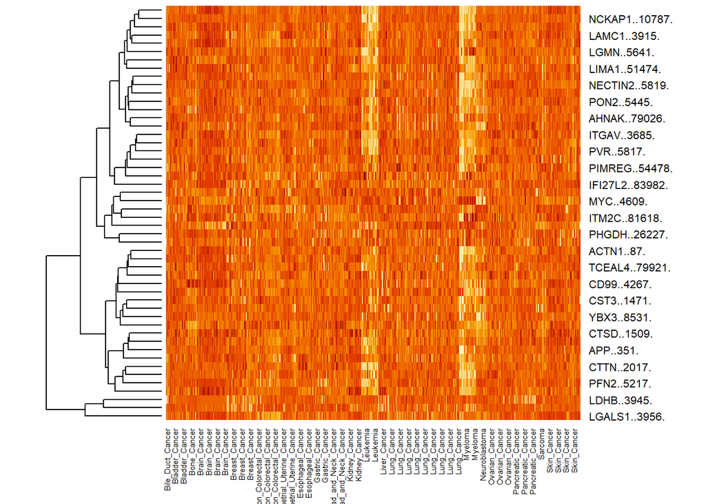

```r
#HeatMap dos 50 genes diferencialmente expressos
rownames(inv_CCLE_expression1) <- make.names(rownames(inv_CCLE_expression1), unique = TRUE)
tt = rowttests(inv_CCLE_expression1)
rank = order(tt$p.value)
p50 = rank[1:50]
Best50 = inv_CCLE_expression1[p50,]
order_cols = order(Sample_Info$primary_disease)
Best50 = Best50[,order_cols]
heatmap(Best50, Colv = NA, labCol = sort(Sample_Info$primary_disease))
```

Para a realização da análise diferencial foi criado um objeto DGE, a partir da função DGEList, que armazena os dados de expressão presentes no dataset. De modo a facilitar a analise de expressão são criados grupos para as várias linhas celulares, este grupo representa a Fase do Carcinoma e o grupo de primary_disease em que cada linha celular se insere.

```r
class(inv_CCLE_expression1) <- 'numeric'
y <- DGEList(inv_CCLE_expression1)
group <- factor((paste(Sample_Info$primary_or_metastasis,Sample_Info$primary_disease,sep="_")))
```

Tendo em conta que o nome de todos os genes presentes no dataset apresentam duas nomenclaturas, provenientes de duas bases de dados biológicas diferentes, HGNC symbol & Entrez ID. Para possibilitar a pesquisa de informação dos genes na base de dados *HUGO Gene Nomenclature Committee (HGNC)*, o EntrezID foi removido da nomenclatura. A HGNC é responsável por definir um símbolo universal para gene humano conhecido.

```r
#Definir os nomes dos genes para original
exprname = gsub("\\..*","",rownames(inv_CCLE_expression1))
rownames(inv_CCLE_expression1) = exprname

exprname1 = gsub("\\..*","",colnames(Sub_CCLE_expression1))
colnames(Sub_CCLE_expression1) = exprname1

copyname = gsub("\\..*","",colnames(CopyNumber))
colnames(CopyNumber) = copyname

casname = gsub("\\..*","",colnames(Crispr))
colnames(Crispr) = casname
```

## 5.3 Análise sem thresholds

Precedentemente à aplicação do modelo linear para os níveis de expressão, é criada uma matriz de design para os grupos criados anteriormente, sendo esta criada consoante o número de comparações que se deseja verificar. No nosso caso de estudo, inicialmente pretendia-se comparar as diferentes fases de cancro e as diferenças de cada doença orientada a tecidos diferentes. Após a matriz de design e o objeto DGE terem sido gerados, estes serão aplicados a um modelo linear através da função ‘lmFit’. Este modelo linear irá obter as médias dos genes para cada grupo, de acordo com a matriz design. Criado o modelo, será importante recolher mais informação adicional sobre os genes em estudo. Através da base de dados ‘Org.Hs.eg.db’, obtivemos, para além do símbolo respetivo de cada gene, o nome do gene e a ENTREZID. Toda esta informação adicional sobre os genes será armazenada numa nova coluna no objeto DGE criado com o nome *genes*. Sendo importante para o nosso estudo a comparação da expressão de genes nos vários grupos definidos, torna-se necessário criar uma matriz de contrastes onde serão colocadas todas as comparações de relevo para o nosso estudo.

### 5.3.1 1º matriz de contrastes

Foram assim criadas duas matrizes de contrastes, sendo a primeira matriz focada nas comparações entre as diferentes fases do cancro para o mesmo tecido. No final foi aplicado o threshold de modo a tornar os resultados obtidos biologicamente significantes.

```r
#Design y
design_y <- model.matrix(~ 0 + group)
colnames(design_y) <- levels(group)

#model fit para  e y
fit_y <- lmFit(inv_CCLE_expression1,design_y)

#Annotation
ann <-AnnotationDbi:: select(org.Hs.eg.db,keys=rownames(fit_y),columns=c("ENTREZID","SYMBOL","GENENAME"),keytype="SYMBOL")
ann3 <- ann[ann[!is.na(ann)],]
m = match(rownames(fit_y),ann$SYMBOL)
fit_y$genes = m

#Matrizes com as comparações a realizar
cont.matrix_PvM <- makeContrasts(PMBLADE = Primary_Bladder_Cancer - Metastasis_Bladder_Cancer, PMLung = Primary_Lung_Cancer - Metastasis_Lung_Cancer, PMMye = Primary_Myeloma - Metastasis_Myeloma, PMBrain = Primary_Brain_Cancer - Metastasis_Brain_Cancer, PMBone = Primary_Bone_Cancer - Metastasis_Bone_Cancer, PMPancr = Primary_Pancreatic_Cancer - Metastasis_Pancreatic_Cancer, PMLeuk = Primary_Leukemia - Metastasis_Leukemia, PMOVA = Primary_Ovarian_Cancer - Metastasis_Ovarian_Cancer, PMRHA = Primary_Rhabdoid - Metastasis_Rhabdoid, PMBREA = Primary_Breast_Cancer - Metastasis_Breast_Cancer, PMKIDN = Primary_Kidney_Cancer - Metastasis_Kidney_Cancer, PMTHY = Primary_Thyroid_Cancer - Metastasis_Thyroid_Cancer, PMSAR = Primary_Sarcoma - Metastasis_Sarcoma, PMHN = Primary_Head_and_Neck_Cancer - Metastasis_Head_and_Neck_Cancer, PMLIVER = Primary_Liver_Cancer - Metastasis_Liver_Cancer, PMSKIN = Primary_Skin_Cancer - Metastasis_Skin_Cancer, PMColon= Primary_Colon_Colorectal_Cancer - Metastasis_Colon_Colorectal_Cancer, PMEYE = Primary_Eye_Cancer - Metastasis_Eye_Cancer, PMBile = Primary_Bile_Duct_Cancer - Metastasis_Bile_Duct_Cancer,PMLYMPH = Primary_Lymphoma - Metastasis_Lymphoma, PMGast = Primary_Gastric_Cancer - Metastasis_Gastric_Cancer, PMEndo = Primary_Endometrial_Uterine_Cancer  - Metastasis_Endometrial_Uterine_Cancer, PMEso = Primary_Esophageal_Cancer - Metastasis_Esophageal_Cancer, PMNeur = Primary_Neuroblastoma - Metastasis_Neuroblastoma, PMCerv = Primary_Cervical_Cancer - Metastasis_Cervical_Cancer , levels=design_y)



#Implementar o modelo fit às condições definidas
fit.cont_PvM <- contrasts.fit(fit_y,cont.matrix_PvM)
fit.cont_PvM <- eBayes(fit.cont_PvM)
dim(fit.cont_PvM)
```

```
## [1] 2062   25
```

```r
summa.fit_PvM<- decideTests(fit.cont_PvM)
summary(summa.fit_PvM)
```

```
##        PMBLADE PMLung PMMye PMBrain PMBone PMPancr PMLeuk PMOVA PMRHA PMBREA
## Down         0      1    27      52     20       3      8     5    13     11
## NotSig    2062   2061  2028    1813   2028    2059   2017  2056  2034   1980
## Up           0      0     7     197     14       0     37     1    15     71
##        PMKIDN PMTHY PMSAR PMHN PMLIVER PMSKIN PMColon PMEYE PMBile PMLYMPH
## Down        1     2     0    0       4     12       1    14      0      52
## NotSig   2061  2060  2062 2062    2057   2050    2054  2033   2062    1998
## Up          0     0     0    0       1      0       7    15      0      12
##        PMGast PMEndo PMEso PMNeur PMCerv
## Down        0      0     2      4      0
## NotSig   2061   2062  2060   2056   2062
## Up          1      0     0      2      0
```

```r
#Verifcar expressão diferencial por tresholds
#Dataset expression
fit.treat_PvM <- treat(fit.cont_PvM,lfc=log2(1.2))
res.treat_PvM <- decideTests(fit.treat_PvM)
summary(res.treat_PvM)
```

```
##        PMBLADE PMLung PMMye PMBrain PMBone PMPancr PMLeuk PMOVA PMRHA PMBREA
## Down         0      0    25      43     16       0      2     2    13      3
## NotSig    2062   2062  2032    1856   2039    2062   2039  2060  2034   2037
## Up           0      0     5     163      7       0     21     0    15     22
##        PMKIDN PMTHY PMSAR PMHN PMLIVER PMSKIN PMColon PMEYE PMBile PMLYMPH
## Down        1     2     0    0       4      7       1    13      0      45
## NotSig   2061  2060  2062 2062    2057   2055    2056  2034   2062    2008
## Up          0     0     0    0       1      0       5    15      0       9
##        PMGast PMEndo PMEso PMNeur PMCerv
## Down        0      0     2      4      0
## NotSig   2062   2062  2060   2057   2062
## Up          0      0     0      1      0
```

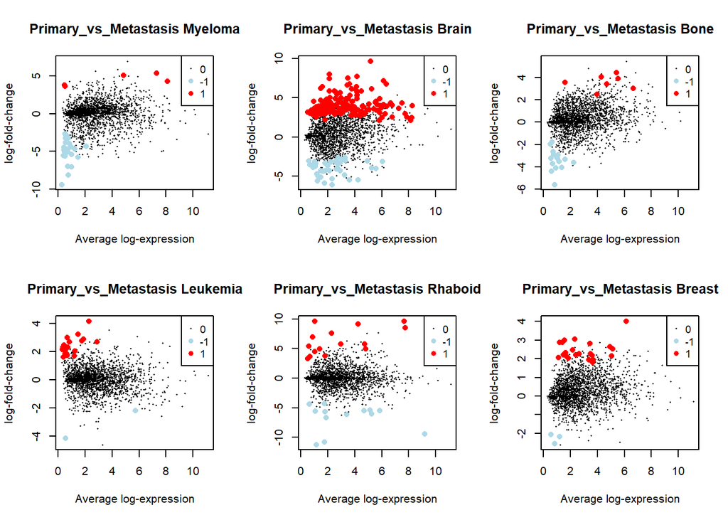

```r
#Gráficos para cada contraste de PvM
par(mfrow = c(2, 3))
plotMD(fit.treat_PvM,coef=3,status=res.treat_PvM[,"PMMye"], values = c(-1, 1), hl.col=c("lightblue","red"), main = 'Primary_vs_Metastasis Myeloma')
plotMD(fit.treat_PvM,coef=4,status=res.treat_PvM[,"PMBrain"], values = c(-1, 1), hl.col=c("lightblue","red"), main = 'Primary_vs_Metastasis Brain')
plotMD(fit.treat_PvM,coef=5,status=res.treat_PvM[,"PMBone"], values = c(-1, 1), hl.col=c("lightblue","red"), main = 'Primary_vs_Metastasis Bone')
plotMD(fit.treat_PvM,coef=7,status=res.treat_PvM[,"PMLeuk"], values = c(-1, 1), hl.col=c("lightblue","red"), main = 'Primary_vs_Metastasis Leukemia')
plotMD(fit.treat_PvM,coef=9,status=res.treat_PvM[,"PMRHA"], values = c(-1, 1), hl.col=c("lightblue","red"), main = 'Primary_vs_Metastasis Rhaboid')
plotMD(fit.treat_PvM,coef=10,status=res.treat_PvM[,"PMBREA"], values = c(-1, 1), hl.col=c("lightblue","red"), main = 'Primary_vs_Metastasis Breast')
```

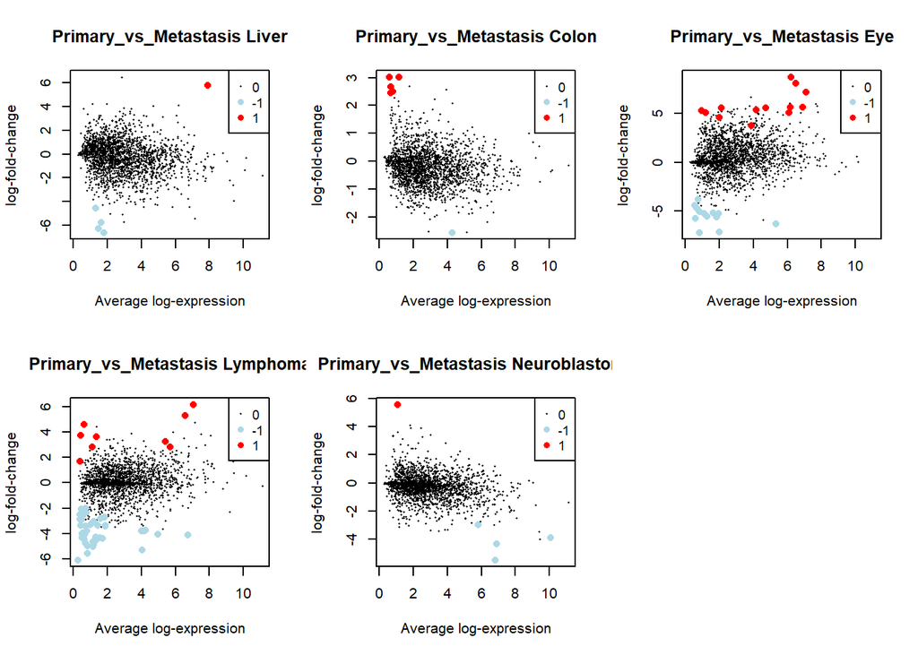

```r
plotMD(fit.treat_PvM,coef=15,status=res.treat_PvM[,"PMLIVER"], values = c(-1, 1), hl.col=c("lightblue","red"), main = 'Primary_vs_Metastasis Liver')
plotMD(fit.treat_PvM,coef=17,status=res.treat_PvM[,"PMColon"], values = c(-1, 1), hl.col=c("lightblue","red"), main = 'Primary_vs_Metastasis Colon')
plotMD(fit.treat_PvM,coef=18,status=res.treat_PvM[,"PMEYE"], values = c(-1, 1), hl.col=c("lightblue","red"), main = 'Primary_vs_Metastasis Eye')
plotMD(fit.treat_PvM,coef=20,status=res.treat_PvM[,"PMLYMPH"], values = c(-1, 1), hl.col=c("lightblue","red"), main = 'Primary_vs_Metastasis Lymphoma')
plotMD(fit.treat_PvM,coef=24,status=res.treat_PvM[,"PMNeur"], values = c(-1, 1), hl.col=c("lightblue","red"), main = 'Primary_vs_Metastasis Neuroblastoma')
```

Como resultados nos vários contrastes existe uma pequena diferença de genes que mantém diferenças significativas a nível de expressão, os genes de interesse para estes casos são só genes que se encontram *up regulated* uma vez que serão genes que estarão mais expressos na fase primária e por isso um gene com importância para a sobrevivência do cancro na fase inicial.

Com estes genes foi realizado a Análise de Enriquecimento para as comparações.

### 5.3.2 Análise de enriquecimento

```r
goPMye <-goana(fit.treat_PvM, coef="PMMye",species = "Hs", geneid=fit.treat_PvM$genes)
topGO(goPMye, n=10, sort = 'Up')
```

```
##                                                                                    Term
## GO:0070374                                 positive regulation of ERK1 and ERK2 cascade
## GO:0002525                        acute inflammatory response to non-antigenic stimulus
## GO:0005520                                           insulin-like growth factor binding
## GO:0002865     negative regulation of acute inflammatory response to antigenic stimulus
## GO:0002878 negative regulation of acute inflammatory response to non-antigenic stimulus
## GO:0002862           negative regulation of inflammatory response to antigenic stimulus
## GO:0031858          pituitary adenylate cyclase-activating polypeptide receptor binding
## GO:0016521                  pituitary adenylate cyclase activating polypeptide activity
## GO:0070318                                   positive regulation of G0 to G1 transition
## GO:0090274                                positive regulation of somatostatin secretion
##            Ont  N Up Down        P.Up P.Down
## GO:0070374  BP 33  2    0 0.002270677      1
## GO:0002525  BP  1  1    0 0.002424242      1
## GO:0005520  MF  1  1    0 0.002424242      1
## GO:0002865  BP  1  1    0 0.002424242      1
## GO:0002878  BP  1  1    0 0.002424242      1
## GO:0002862  BP  1  1    0 0.002424242      1
## GO:0031858  MF  1  1    0 0.002424242      1
## GO:0016521  MF  1  1    0 0.002424242      1
## GO:0070318  BP  1  1    0 0.002424242      1
## GO:0090274  BP  1  1    0 0.002424242      1
```

```r
goPMBrain <- goana(fit.treat_PvM, coef="PMBrain",species = "Hs", geneid=fit.treat_PvM$genes)
topGO(goPMBrain, n=10, sort = 'Up')
```

```
##                                                       Term Ont  N Up Down
## GO:0045652     regulation of megakaryocyte differentiation  BP  3  3    0
## GO:0045637      regulation of myeloid cell differentiation  BP 30  8    0
## GO:0030219                   megakaryocyte differentiation  BP  4  3    0
## GO:0008308            voltage-gated anion channel activity  MF  9  4    0
## GO:0005247         voltage-gated chloride channel activity  MF  9  4    0
## GO:0022832                  voltage-gated channel activity  MF 28  7    0
## GO:0005244              voltage-gated ion channel activity  MF 28  7    0
## GO:0140101            catalytic activity, acting on a tRNA  MF  5  3    0
## GO:0036037      CD8-positive, alpha-beta T cell activation  BP  5  3    0
## GO:0043374 CD8-positive, alpha-beta T cell differentiation  BP  5  3    0
##                    P.Up P.Down
## GO:0045652 0.0003480807      1
## GO:0045637 0.0007852046      1
## GO:0030219 0.0013200436      1
## GO:0008308 0.0022913752      1
## GO:0005247 0.0022913752      1
## GO:0022832 0.0025519030      1
## GO:0005244 0.0025519030      1
## GO:0140101 0.0031293354      1
## GO:0036037 0.0031293354      1
## GO:0043374 0.0031293354      1
```

```r
goPMBone <-goana(fit.treat_PvM, coef="PMBone",species = "Hs", geneid=fit.treat_PvM$genes)
topGO(goPMBone, n=10, sort = 'Up')
```

```
##                                                                          Term
## GO:0017096                       acetylserotonin O-methyltransferase activity
## GO:0140327                                                  flippase activity
## GO:0140333                              glycerophospholipid flippase activity
## GO:0097411                  hypoxia-inducible factor-1alpha signaling pathway
## GO:0090555                         phosphatidylethanolamine flippase activity
## GO:0006649                                  phospholipid transfer to membrane
## GO:1905820                       positive regulation of chromosome separation
## GO:1902101 positive regulation of metaphase/anaphase transition of cell cycle
## GO:0045842       positive regulation of mitotic metaphase/anaphase transition
## GO:0062033        positive regulation of mitotic sister chromatid segregation
##            Ont N Up Down        P.Up P.Down
## GO:0017096  MF 1  1    0 0.003636364      1
## GO:0140327  MF 1  1    0 0.003636364      1
## GO:0140333  MF 1  1    0 0.003636364      1
## GO:0097411  BP 1  1    0 0.003636364      1
## GO:0090555  MF 1  1    0 0.003636364      1
## GO:0006649  BP 1  1    0 0.003636364      1
## GO:1905820  BP 1  1    0 0.003636364      1
## GO:1902101  BP 1  1    0 0.003636364      1
## GO:0045842  BP 1  1    0 0.003636364      1
## GO:0062033  BP 1  1    0 0.003636364      1
```

```r
goPMLeuk <- goana(fit.treat_PvM, coef="PMLeuk",species = "Hs", geneid = fit.treat_PvM$genes)
topGO(goPMLeuk, n=10, sort = 'Up')
```

```
##                                                            Term Ont   N Up Down
## GO:0006730                         one-carbon metabolic process  BP  13  3    0
## GO:0002092      positive regulation of receptor internalization  BP   6  2    0
## GO:0044281                     small molecule metabolic process  BP 314  8    1
## GO:0042398    cellular modified amino acid biosynthetic process  BP   9  2    0
## GO:0004089                       carbonate dehydratase activity  MF  10  2    0
## GO:0002090               regulation of receptor internalization  BP  11  2    0
## GO:0015701                                bicarbonate transport  BP  13  2    0
## GO:0016829                                       lyase activity  MF  45  3    0
## GO:0050906 detection of stimulus involved in sensory perception  BP  14  2    0
## GO:0048260 positive regulation of receptor-mediated endocytosis  BP  15  2    0
##                    P.Up   P.Down
## GO:0006730 0.0001324748 1.000000
## GO:0002092 0.0009840261 1.000000
## GO:0044281 0.0016300903 0.190303
## GO:0042398 0.0023274631 1.000000
## GO:0004089 0.0028952217 1.000000
## GO:0002090 0.0035214487 1.000000
## GO:0015701 0.0049457605 1.000000
## GO:0016829 0.0055938700 1.000000
## GO:0050906 0.0057420941 1.000000
## GO:0048260 0.0065933938 1.000000
```

```r
goPMRHA <- goana(fit.treat_PvM, coef="PMRHA",species = "Hs", geneid=fit.treat_PvM$genes)
topGO(goPMRHA, n=10, sort = 'Up')
```

```
##                                                     Term Ont   N Up Down
## GO:0009719               response to endogenous stimulus  BP 292  7    3
## GO:0044703           multi-organism reproductive process  BP 122  5    0
## GO:0007276                             gamete generation  BP  67  4    0
## GO:0051704                        multi-organism process  BP 130  5    0
## GO:0048608            reproductive structure development  BP  70  4    0
## GO:0061458               reproductive system development  BP  70  4    0
## GO:0042448                progesterone metabolic process  BP   7  2    0
## GO:0008406                             gonad development  BP  33  3    0
## GO:0019953                           sexual reproduction  BP  83  4    0
## GO:0045137 development of primary sexual characteristics  BP  36  3    0
##                    P.Up    P.Down
## GO:0009719 0.0003755015 0.2025488
## GO:0044703 0.0003802363 1.0000000
## GO:0007276 0.0004342220 1.0000000
## GO:0051704 0.0005139330 1.0000000
## GO:0048608 0.0005147909 1.0000000
## GO:0061458 0.0005147909 1.0000000
## GO:0042448 0.0006834673 1.0000000
## GO:0008406 0.0007957641 1.0000000
## GO:0019953 0.0009922398 1.0000000
## GO:0045137 0.0010313681 1.0000000
```

```r
goPMBREA <-goana(fit.treat_PvM, coef="PMBREA",species = "Hs", geneid=fit.treat_PvM$genes)
topGO(goPMBREA, n=10, sort = 'Up')
```

```
##                                                                          Term
## GO:0008213                                                 protein alkylation
## GO:0006479                                                protein methylation
## GO:0098632                               cell-cell adhesion mediator activity
## GO:0098631                                    cell adhesion mediator activity
## GO:0043414                                          macromolecule methylation
## GO:0005912                                                  adherens junction
## GO:0030154                                               cell differentiation
## GO:0032259                                                        methylation
## GO:0047006 17-alpha,20-alpha-dihydroxypregn-4-en-3-one dehydrogenase activity
## GO:0043102                                                 amino acid salvage
##            Ont   N Up Down        P.Up P.Down
## GO:0008213  BP   7  2    0 0.002286367      1
## GO:0006479  BP   7  2    0 0.002286367      1
## GO:0098632  MF  10  2    0 0.004805045      1
## GO:0098631  MF  10  2    0 0.004805045      1
## GO:0043414  BP  10  2    0 0.004805045      1
## GO:0005912  CC  37  3    0 0.006720073      1
## GO:0030154  BP 529 11    0 0.010165720      1
## GO:0032259  BP  15  2    0 0.010854911      1
## GO:0047006  MF   1  1    0 0.010909091      1
## GO:0043102  BP   1  1    0 0.010909091      1
```

```r
goPMLIVER <- goana(fit.treat_PvM, coef="PMLIVER",species = "Hs", geneid = fit.treat_PvM$genes)
topGO(goPMLIVER, n=10, sort = 'Up')
```

```
##                                                              Term Ont N Up Down
## GO:0030523            dihydrolipoamide S-acyltransferase activity  MF 1  1    0
## GO:0004742 dihydrolipoyllysine-residue acetyltransferase activity  MF 1  1    0
## GO:0005967           mitochondrial pyruvate dehydrogenase complex  CC 1  1    0
## GO:0016418                           S-acetyltransferase activity  MF 1  1    0
## GO:0006086          acetyl-CoA biosynthetic process from pyruvate  BP 2  1    0
## GO:0034604                 pyruvate dehydrogenase (NAD+) activity  MF 2  1    0
## GO:0034603              pyruvate dehydrogenase [NAD(P)+] activity  MF 2  1    0
## GO:0004738                        pyruvate dehydrogenase activity  MF 2  1    0
## GO:0045254                         pyruvate dehydrogenase complex  CC 2  1    0
## GO:0016417                             S-acyltransferase activity  MF 2  1    0
##                    P.Up P.Down
## GO:0030523 0.0006060606      1
## GO:0004742 0.0006060606      1
## GO:0005967 0.0006060606      1
## GO:0016418 0.0006060606      1
## GO:0006086 0.0012121212      1
## GO:0034604 0.0012121212      1
## GO:0034603 0.0012121212      1
## GO:0004738 0.0012121212      1
## GO:0045254 0.0012121212      1
## GO:0016417 0.0012121212      1
```

```r
goPMColon <- goana(fit.treat_PvM, coef="PMColon",species = "Hs", geneid = fit.treat_PvM$genes)
topGO(goPMColon, n=10, sort = 'Up')
```

```
##                                                           Term Ont  N Up Down
## GO:0032000    positive regulation of fatty acid beta-oxidation  BP  4  2    0
## GO:0046321         positive regulation of fatty acid oxidation  BP  4  2    0
## GO:0031998             regulation of fatty acid beta-oxidation  BP  7  2    0
## GO:0046320                  regulation of fatty acid oxidation  BP  9  2    0
## GO:1902001                  fatty acid transmembrane transport  BP 10  2    0
## GO:0050996      positive regulation of lipid catabolic process  BP 10  2    0
## GO:0030258                                  lipid modification  BP 58  3    0
## GO:0045923 positive regulation of fatty acid metabolic process  BP 11  2    0
## GO:0032365                       intracellular lipid transport  BP 12  2    0
## GO:1905039             carboxylic acid transmembrane transport  BP 14  2    0
##                    P.Up P.Down
## GO:0032000 4.399687e-05      1
## GO:0046321 4.399687e-05      1
## GO:0031998 1.534286e-04      1
## GO:0046320 2.623813e-04      1
## GO:1902001 3.275778e-04      1
## GO:0050996 3.275778e-04      1
## GO:0030258 3.924745e-04      1
## GO:0045923 3.998858e-04      1
## GO:0032365 4.792790e-04      1
## GO:1905039 6.592159e-04      1
```

```r
goPMEYE <- goana(fit.treat_PvM, coef="PMEYE",species = "Hs", geneid = fit.treat_PvM$genes)
topGO(goPMEYE, n=10, sort = 'Up')
```

```
##                                                                                                         Term
## GO:0003823                                                                                   antigen binding
## GO:0071839                                                             apoptotic process in bone marrow cell
## GO:0016320                                                             endoplasmic reticulum membrane fusion
## GO:1902236 negative regulation of endoplasmic reticulum stress-induced intrinsic apoptotic signaling pathway
## GO:0015112                                                        nitrate transmembrane transporter activity
## GO:0015706                                                                                 nitrate transport
## GO:1900022                                               regulation of D-erythro-sphingosine kinase activity
## GO:0046898                                                                         response to cycloheximide
## GO:0097194                                                                      execution phase of apoptosis
## GO:0003985                                                           acetyl-CoA C-acetyltransferase activity
##            Ont  N Up Down        P.Up       P.Down
## GO:0003823  MF  9  2    2 0.002000640 0.0009339143
## GO:0071839  BP  1  1    0 0.007878788 1.0000000000
## GO:0016320  BP  1  1    0 0.007878788 1.0000000000
## GO:1902236  BP  1  1    0 0.007878788 1.0000000000
## GO:0015112  MF  1  1    0 0.007878788 1.0000000000
## GO:0015706  BP  1  1    0 0.007878788 1.0000000000
## GO:1900022  BP  1  1    0 0.007878788 1.0000000000
## GO:0046898  BP  1  1    0 0.007878788 1.0000000000
## GO:0097194  BP 23  2    0 0.013210294 1.0000000000
## GO:0003985  MF  2  1    0 0.015700241 1.0000000000
```

```r
goPMLYMPH <- goana(fit.treat_PvM, coef="PMLYMPH",species = "Hs", geneid = fit.treat_PvM$genes)
topGO(goPMLYMPH, n=10, sort = 'Up')
```

```
##                                                   Term Ont   N Up Down
## GO:0030317                  flagellated sperm motility  BP   8  2    0
## GO:0097722                              sperm motility  BP   8  2    0
## GO:0060294   cilium movement involved in cell motility  BP   9  2    0
## GO:0060285              cilium-dependent cell motility  BP  10  2    0
## GO:0001539 cilium or flagellum-dependent cell motility  BP  10  2    0
## GO:0031904                              endosome lumen  CC  10  2    0
## GO:0003341                             cilium movement  BP  12  2    0
## GO:0040011                                  locomotion  BP 268  5    4
## GO:0034360                         chylomicron remnant  CC   1  1    0
## GO:1904155               DN2 thymocyte differentiation  BP   1  1    0
##                    P.Up    P.Down
## GO:0030317 0.0005679456 1.0000000
## GO:0097722 0.0005679456 1.0000000
## GO:0060294 0.0007284418 1.0000000
## GO:0060285 0.0009083398 1.0000000
## GO:0001539 0.0009083398 1.0000000
## GO:0031904 0.0009083398 1.0000000
## GO:0003341 0.0013257642 1.0000000
## GO:0040011 0.0040019922 0.8883408
## GO:0034360 0.0048484848 1.0000000
## GO:1904155 0.0048484848 1.0000000
```

```r
goPMNeur <- goana(fit.treat_PvM, coef="PMNeur",species = "Hs", geneid = fit.treat_PvM$genes)
topGO(goPMNeur, n=10, sort = 'Up')
```

```
##                                                                                                                     Term
## GO:0044210                                                                            'de novo' CTP biosynthetic process
## GO:0070626 (S)-2-(5-amino-1-(5-phospho-D-ribosyl)imidazole-4-carboxamido)succinate AMP-lyase (fumarate-forming) activity
## GO:0047298                                                          (S)-3-amino-2-methylpropionate transaminase activity
## GO:0030342                                                        1-alpha,25-dihydroxyvitamin D3 24-hydroxylase activity
## GO:0016303                                                                      1-phosphatidylinositol-3-kinase activity
## GO:0033737                                                                            1-pyrroline dehydrogenase activity
## GO:0004645                                                                  1,4-alpha-oligoglucan phosphorylase activity
## GO:0102320                                                                      1,8-cineole 2-exo-monooxygenase activity
## GO:0033885                                                 10-hydroxy-9-(phosphonooxy)octadecanoate phosphatase activity
## GO:0047020                                                      15-hydroxyprostaglandin-D dehydrogenase (NADP+) activity
##            Ont N Up Down P.Up P.Down
## GO:0044210  BP 1  0    0    1      1
## GO:0070626  MF 1  0    0    1      1
## GO:0047298  MF 1  0    0    1      1
## GO:0030342  MF 1  0    0    1      1
## GO:0016303  MF 1  0    0    1      1
## GO:0033737  MF 1  0    0    1      1
## GO:0004645  MF 1  0    0    1      1
## GO:0102320  MF 1  0    0    1      1
## GO:0033885  MF 1  0    0    1      1
## GO:0047020  MF 1  0    0    1      1
```

**Cancro dos Ossos Primário vs Metastásico** No cancro dos **Ossos** foram encontrados genes associados **desenvolvimento celular**, **transporte de lipídios para o meio intracelular** e **aumento da fase anafásica/metafasica**.

**Cancro Mamário primário vs Metastásico** No cancro **Mamário** foram encontrados genes associados **proliferação celular**, **adesão celular e favorecendo da interação célula-célula** e **aumento da taxa de produção de aminoácidos**.

**Cancro ocular Primário vs Metastásico** No cancro **ocular** foram encontrados genes associados ao **controlo da apoptose celular a partir das Caspases**, **ligação a antigénio (impedindo resposta imune)** , **inibição do processo de apoptose do reticulo endoplasmático**.

**Leucemia Primário vs Metastásico** Na **Leucemia** foram encontrados genes associados ao aumento **da regulação de vários recetores extracelulares**, **endocitose** e **anabolismo aminoácidico** .

**Cancro do Fígado Primário vs Metastásico** No cancro do **Fígado** foram encontrados genes associados **à catalisação de reações de CoA e de Piruvato**.

**Linfoma Primário vs Metastásico** No **Linfoma** foram encontrados genes associados à **locomoção celular (formação de Cília)** , **diferenciação celular** e **inibição do sistema imunitário**.

**Mieloma Tecido Primário vs Metastásico** No **Mieloma** foram encontrados genes associados a processos **de ativação do ciclo celular**, **previnem respostas de inflamação** , **ligações a recetores responsáveis por estimulação da proliferação e diferenciação celular**.

**Rabdóide Primário vs Metastásico** No **Rabdóide** foram encontrados genes associados ao **crescimento e desenvolvimento celular**, **modificação da produção de enzimas secreção** e **alteração da expressão genética**.

### 5.3.3 2º matriz de contrastes

A segunda matriz realiza as comparações entre todos tipos de cancro, realizando sempre uma espécie de *one vs all*. A segunda matriz foi construída a descobrir os genes se encontravam mais frequentemente *overexpressed* em um tecido em relação a todos os cancros restantes. Desta forma foi apenas usado apenas o grupo dividindo o dataset por tecido sem consideração da fase de carcinoma.

```r
group2 <- factor((paste(Sample_Info$primary_disease)))
table(group2)
```

```
## group2
##           Bile_Duct_Cancer             Bladder_Cancer
##                          5                         26
##                Bone_Cancer               Brain_Cancer
##                         15                         41
##              Breast_Cancer            Cervical_Cancer
##                         35                         10
##    Colon_Colorectal_Cancer Endometrial_Uterine_Cancer
##                         33                         25
##          Esophageal_Cancer                 Eye_Cancer
##                         18                          5
##             Gastric_Cancer       Head_and_Neck_Cancer
##                         25                         25
##              Kidney_Cancer                   Leukemia
##                         19                         24
##               Liver_Cancer                Lung_Cancer
##                         17                        100
##                   Lymphoma                    Myeloma
##                          8                         16
##              Neuroblastoma             Ovarian_Cancer
##                         14                         42
##          Pancreatic_Cancer                   Rhabdoid
##                         31                          4
##                    Sarcoma                Skin_Cancer
##                         11                         43
##             Thyroid_Cancer
##                          6
```

```r
#Design y
design_y2 <- model.matrix(~ 0 + group2)
colnames(design_y2) <- levels(group2)

#model fit para  e y
fit_y2 <- lmFit(inv_CCLE_expression1,design_y2)

#Annotation
ann1 <-AnnotationDbi:: select(org.Hs.eg.db,keys=rownames(fit_y2),columns=c("ENTREZID","SYMBOL","GENENAME"),keytype="SYMBOL")
ann4 <- ann1[ann1[!is.na(ann1)],]
m = match(rownames(fit_y2),ann$SYMBOL)
fit_y2$genes = m

#Matrizes com as comparações a realizar
cont.matrix_linhage <- makeContrasts(LunBla = Lung_Cancer - Bladder_Cancer , LunBrea = Lung_Cancer - Breast_Cancer ,LunEso = Lung_Cancer - Esophageal_Cancer ,
                                     LunKid = Lung_Cancer - Kidney_Cancer ,LunLym = Lung_Cancer - Lymphoma ,LunPanc = Lung_Cancer - Pancreatic_Cancer ,
                                     LunThyr = Lung_Cancer - Thyroid_Cancer,LunBile = Lung_Cancer - Bile_Duct_Cancer ,
                                     LunCer = Lung_Cancer - Cervical_Cancer ,LunEye = Lung_Cancer - Eye_Cancer ,LunLeuk = Lung_Cancer - Leukemia ,
                                     LunMye = Lung_Cancer - Myeloma,LunRhab = Lung_Cancer - Rhabdoid, LunSar = Lung_Cancer - Sarcoma,
                                     LunSkin = Lung_Cancer - Skin_Cancer, LunBone = Lung_Cancer - Bone_Cancer, LunBrain = Lung_Cancer - Brain_Cancer,
                                     LunColon = Lung_Cancer - Colon_Colorectal_Cancer, LunEndo = Lung_Cancer - Endometrial_Uterine_Cancer, LunGas = Lung_Cancer - Gastric_Cancer,
                                    LunHead = Lung_Cancer - Head_and_Neck_Cancer, LunLiver = Lung_Cancer - Liver_Cancer, LunNeuro = Lung_Cancer - Neuroblastoma,
                                    LunOvar = Lung_Cancer - Ovarian_Cancer, BileBlad = Bile_Duct_Cancer - Bladder_Cancer, BileBone = Bile_Duct_Cancer - Bone_Cancer, BileBrain = Bile_Duct_Cancer - Brain_Cancer
                                    , BileBreast = Bile_Duct_Cancer - Breast_Cancer, BileCerv = Bile_Duct_Cancer - Cervical_Cancer, BileColo = Bile_Duct_Cancer - Colon_Colorectal_Cancer,
                                    BileEndo = Bile_Duct_Cancer - Endometrial_Uterine_Cancer, BileEsoph = Bile_Duct_Cancer - Esophageal_Cancer, BileEye = Bile_Duct_Cancer - Eye_Cancer,
                                    BileGast = Bile_Duct_Cancer - Gastric_Cancer, BileHead = Bile_Duct_Cancer - Head_and_Neck_Cancer, BileKid = Bile_Duct_Cancer - Kidney_Cancer, BileLeuk = Bile_Duct_Cancer - Leukemia,
                                    BileLiver = Bile_Duct_Cancer - Liver_Cancer, BileLym = Bile_Duct_Cancer - Lymphoma, BileMyel = Bile_Duct_Cancer - Myeloma, BileNeuro = Bile_Duct_Cancer - Neuroblastoma,
                                    BileOvar = Bile_Duct_Cancer - Ovarian_Cancer, BilePancre = Bile_Duct_Cancer - Pancreatic_Cancer, BileRhab = Bile_Duct_Cancer - Rhabdoid, BileSarc = Bile_Duct_Cancer - Sarcoma,
                                    BileSkin = Bile_Duct_Cancer - Skin_Cancer, BileThyr = Bile_Duct_Cancer - Thyroid_Cancer, BladBone = Bladder_Cancer - Bone_Cancer, BladBrain = Bladder_Cancer - Brain_Cancer, BladBreas = Bladder_Cancer - Breast_Cancer,
                                    BladCerv = Bladder_Cancer - Cervical_Cancer, BladColon = Bladder_Cancer - Colon_Colorectal_Cancer, BladEndo = Bladder_Cancer - Endometrial_Uterine_Cancer, BladEsoph = Bladder_Cancer - Esophageal_Cancer,
                                    BladEye = Bladder_Cancer - Eye_Cancer, BladGastr = Bladder_Cancer - Gastric_Cancer, BladHead = Bladder_Cancer - Head_and_Neck_Cancer, BladKidn = Bladder_Cancer - Kidney_Cancer, BladLeuk = Bladder_Cancer - Leukemia, BladLive = Bladder_Cancer - Liver_Cancer,
                                    BladLymp = Bladder_Cancer - Lymphoma, BladMyel = Bladder_Cancer - Myeloma, BladNeurob = Bladder_Cancer - Neuroblastoma, BladOvar = Bladder_Cancer - Ovarian_Cancer, BladPanc = Bladder_Cancer - Pancreatic_Cancer, BladRha = Bladder_Cancer - Rhabdoid, BladSarc = Bladder_Cancer - Sarcoma,
                                    BladSkin = Bladder_Cancer - Skin_Cancer, BladThyr = Bladder_Cancer - Thyroid_Cancer, BoneBrain = Bone_Cancer - Brain_Cancer, BoneBreas = Bone_Cancer - Breast_Cancer, BoneCerv = Bone_Cancer - Cervical_Cancer, BoneColon = Bone_Cancer - Colon_Colorectal_Cancer, BoneEndo = Bone_Cancer - Endometrial_Uterine_Cancer, BoneEsop = Bone_Cancer - Esophageal_Cancer,
                                    BoneEye = Bone_Cancer - Eye_Cancer, BoneGast = Bone_Cancer - Gastric_Cancer, BoneHead = Bone_Cancer - Head_and_Neck_Cancer, BoneKid = Bone_Cancer - Kidney_Cancer, BoneLeuk = Bone_Cancer - Leukemia, BoneLive = Bone_Cancer - Liver_Cancer, BoneLymp = Bone_Cancer - Lymphoma, BoneMye = Bone_Cancer - Myeloma, BoneNeuro = Bone_Cancer - Neuroblastoma, BoneOvar = Bone_Cancer - Ovarian_Cancer,
                                    BonePanc = Bone_Cancer - Pancreatic_Cancer, BoneRha = Bone_Cancer - Rhabdoid, BoneSarc = Bone_Cancer - Sarcoma, BoneSkin = Bone_Cancer - Skin_Cancer, BoneThyr = Bone_Cancer - Thyroid_Cancer, BrainBreas = Brain_Cancer - Breast_Cancer, BrainCerv = Brain_Cancer - Cervical_Cancer, BrainColon = Brain_Cancer - Colon_Colorectal_Cancer, BrainEndo = Brain_Cancer - Endometrial_Uterine_Cancer, BrainEsoph = Brain_Cancer - Esophageal_Cancer,
                                    BrainEye = Brain_Cancer - Eye_Cancer, BrainGast = Brain_Cancer - Gastric_Cancer, BrainHead = Brain_Cancer - Head_and_Neck_Cancer, BrainKid = Brain_Cancer - Kidney_Cancer, BrainLeuk = Brain_Cancer - Leukemia, BrainLiver = Brain_Cancer - Liver_Cancer, BrainLym = Brain_Cancer - Lymphoma, BrainMye = Brain_Cancer - Myeloma, BrainNeuro = Brain_Cancer - Neuroblastoma, BrainOvar = Brain_Cancer - Ovarian_Cancer, BrainPanc = Brain_Cancer - Pancreatic_Cancer,
                                    BrainRha = Brain_Cancer - Rhabdoid, BrainSarc = Brain_Cancer -Sarcoma, BrainSkin = Brain_Cancer - Skin_Cancer, BrainThy = Brain_Cancer - Thyroid_Cancer,
                                    BreastCerv = Breast_Cancer - Cervical_Cancer, BreastColon = Breast_Cancer - Colon_Colorectal_Cancer, BreastEndo = Breast_Cancer - Endometrial_Uterine_Cancer, BreastEsoph = Breast_Cancer - Esophageal_Cancer, BreastEye = Breast_Cancer - Eye_Cancer, BreastGastr = Breast_Cancer - Gastric_Cancer, BreastHead = Breast_Cancer - Head_and_Neck_Cancer, BreastKid = Breast_Cancer - Kidney_Cancer, BreastLeuk = Breast_Cancer - Leukemia, BreastLiver = Breast_Cancer - Liver_Cancer,
                                    BreastPanc = Breast_Cancer - Pancreatic_Cancer, BreastRhab = Breast_Cancer - Rhabdoid, BreastSarc = Breast_Cancer - Sarcoma, BreastSkin = Breast_Cancer - Skin_Cancer, BreastThy = Breast_Cancer - Thyroid_Cancer, CervColon = Cervical_Cancer - Colon_Colorectal_Cancer, CervEndo = Cervical_Cancer - Endometrial_Uterine_Cancer, CervEsoph = Cervical_Cancer - Esophageal_Cancer,CervEye = Cervical_Cancer - Eye_Cancer, CervGast = Cervical_Cancer - Gastric_Cancer, CervHead = Cervical_Cancer - Head_and_Neck_Cancer,
                                    CervKid = Cervical_Cancer - Kidney_Cancer, CervLeuk = Cervical_Cancer - Leukemia, CervLiver = Cervical_Cancer - Liver_Cancer, CervLym = Cervical_Cancer - Lymphoma, CervMye = Cervical_Cancer - Myeloma, CervNeuro = Cervical_Cancer - Neuroblastoma, CervOvari = Cervical_Cancer - Ovarian_Cancer, CervPanc = Cervical_Cancer - Pancreatic_Cancer, CervRhab = Cervical_Cancer - Rhabdoid, CervSarc = Cervical_Cancer - Sarcoma, CervSkin = Cervical_Cancer - Skin_Cancer, CervThy = Cervical_Cancer - Thyroid_Cancer, ColonEndo = Colon_Colorectal_Cancer - Endometrial_Uterine_Cancer,
                                    ColonEsoph = Colon_Colorectal_Cancer - Esophageal_Cancer, ColonEye = Colon_Colorectal_Cancer - Eye_Cancer, ColonGast = Colon_Colorectal_Cancer - Gastric_Cancer, ColonHead = Colon_Colorectal_Cancer - Head_and_Neck_Cancer, ColonKid = Colon_Colorectal_Cancer - Kidney_Cancer, ColonLeuk = Colon_Colorectal_Cancer - Leukemia, ColonLiver = Colon_Colorectal_Cancer - Liver_Cancer, ColonLym = Colon_Colorectal_Cancer - Lymphoma, ColonMye = Colon_Colorectal_Cancer - Myeloma, ColonNeuro = Colon_Colorectal_Cancer - Neuroblastoma,
                                    ColonOvari = Colon_Colorectal_Cancer - Ovarian_Cancer, ColonPanc = Colon_Colorectal_Cancer - Pancreatic_Cancer, ColonRhab = Colon_Colorectal_Cancer - Rhabdoid, ColonSarc = Colon_Colorectal_Cancer - Sarcoma, ColonSkin = Colon_Colorectal_Cancer - Skin_Cancer, ColonThy = Colon_Colorectal_Cancer - Thyroid_Cancer,
                                    EndoEsoph = Endometrial_Uterine_Cancer - Esophageal_Cancer, EndoEye = Endometrial_Uterine_Cancer - Eye_Cancer, EndoGast = Endometrial_Uterine_Cancer - Gastric_Cancer, EndoHead = Endometrial_Uterine_Cancer - Head_and_Neck_Cancer, EndoKid = Endometrial_Uterine_Cancer - Kidney_Cancer, EndoLeuk = Endometrial_Uterine_Cancer - Leukemia, EndoLiver = Endometrial_Uterine_Cancer - Liver_Cancer,
                                    EndoLym = Endometrial_Uterine_Cancer - Lymphoma, EndoMye = Endometrial_Uterine_Cancer - Myeloma, EndoNeur = Endometrial_Uterine_Cancer - Neuroblastoma, EndoOvar = Endometrial_Uterine_Cancer - Ovarian_Cancer, EndoPanc = Endometrial_Uterine_Cancer - Pancreatic_Cancer, EndoRhab = Endometrial_Uterine_Cancer - Rhabdoid, EndoSarc = Endometrial_Uterine_Cancer - Sarcoma, EndoSkin = Endometrial_Uterine_Cancer - Skin_Cancer, EndoThy = Endometrial_Uterine_Cancer - Thyroid_Cancer,
                                    EsophEye = Esophageal_Cancer - Eye_Cancer, EsophGast = Esophageal_Cancer - Gastric_Cancer, EsophHead = Esophageal_Cancer - Head_and_Neck_Cancer, EsophKid = Esophageal_Cancer - Kidney_Cancer, EsophLeuk = Esophageal_Cancer - Leukemia, EsophLiver = Esophageal_Cancer - Liver_Cancer, EsophLym = Esophageal_Cancer - Lymphoma, EsophMye = Esophageal_Cancer - Myeloma, EsophNeuro = Esophageal_Cancer - Neuroblastoma, EsophOvar = Esophageal_Cancer - Ovarian_Cancer, EsophPanc = Esophageal_Cancer - Pancreatic_Cancer, EsophRhab = Esophageal_Cancer - Rhabdoid,
                                    EsophSarc = Esophageal_Cancer - Sarcoma, EsophSkin = Esophageal_Cancer - Skin_Cancer, EsophThy = Esophageal_Cancer - Thyroid_Cancer, EyeGast = Eye_Cancer - Gastric_Cancer, EyeHead = Eye_Cancer - Head_and_Neck_Cancer, EyeKid = Eye_Cancer - Kidney_Cancer, EyeLeuk = Eye_Cancer - Leukemia, EyeLiver = Eye_Cancer - Liver_Cancer, EyeLym = Eye_Cancer - Lymphoma, EyeMye = Eye_Cancer - Myeloma, EyeNeur = Eye_Cancer - Neuroblastoma, EyeOvar = Eye_Cancer - Ovarian_Cancer, EyePanc = Eye_Cancer - Pancreatic_Cancer, EyeRhab = Eye_Cancer - Rhabdoid, EyeSarc = Eye_Cancer - Sarcoma, EyeSkin = Eye_Cancer - Skin_Cancer,
                                    EyeThy = Eye_Cancer - Thyroid_Cancer, GastHead = Gastric_Cancer - Head_and_Neck_Cancer,GastKid = Gastric_Cancer - Kidney_Cancer, GastLeuk = Gastric_Cancer - Leukemia, GastLiver = Gastric_Cancer - Liver_Cancer, GastLym = Gastric_Cancer - Lymphoma, GastMye = Gastric_Cancer - Myeloma, GastNeur = Gastric_Cancer - Neuroblastoma, GastOvar = Gastric_Cancer - Ovarian_Cancer, GastPanc = Gastric_Cancer - Pancreatic_Cancer, GastRhab = Gastric_Cancer - Rhabdoid, GastSarc = Gastric_Cancer - Sarcoma, GastSkin = Gastric_Cancer - Skin_Cancer, GastThy = Gastric_Cancer - Thyroid_Cancer,
                                    HeadKid = Head_and_Neck_Cancer - Kidney_Cancer, HeadLeuk = Head_and_Neck_Cancer - Leukemia, HeadLiver = Head_and_Neck_Cancer - Liver_Cancer, HeadLym = Head_and_Neck_Cancer - Lymphoma, HeadMye = Head_and_Neck_Cancer - Myeloma, HeadNeur = Head_and_Neck_Cancer - Neuroblastoma, HeadOvar = Head_and_Neck_Cancer - Ovarian_Cancer, HeadPanc = Head_and_Neck_Cancer - Pancreatic_Cancer, HeadRhab = Head_and_Neck_Cancer - Rhabdoid, HeadSarc = Head_and_Neck_Cancer - Sarcoma, HeadSkin = Head_and_Neck_Cancer - Skin_Cancer, HeadThy = Head_and_Neck_Cancer - Thyroid_Cancer,
                                    KidLeuk = Kidney_Cancer - Leukemia, KidLiver = Kidney_Cancer - Liver_Cancer, KidLym = Kidney_Cancer - Lymphoma, KidMye = Kidney_Cancer - Myeloma, KidNeur = Kidney_Cancer - Neuroblastoma, KidOvar = Kidney_Cancer - Ovarian_Cancer, KidPanc = Kidney_Cancer - Pancreatic_Cancer, KidRhab = Kidney_Cancer - Rhabdoid, KidSarc = Kidney_Cancer - Sarcoma, KidSkin = Kidney_Cancer - Skin_Cancer, KidThy = Kidney_Cancer - Thyroid_Cancer,
```

```r
                                    LeukLiver = Leukemia - Liver_Cancer, LeukLym = Leukemia - Lymphoma, LeukMye = Leukemia - Myeloma, LeukNeur = Leukemia - Neuroblastoma, LeukOvar = Leukemia - Ovarian_Cancer, LeukPanc = Leukemia - Pancreatic_Cancer, LeukRhab = Leukemia - Rhabdoid, LeukSarc = Leukemia - Sarcoma, LeukSkin = Leukemia - Skin_Cancer, LeukThy = Leukemia - Thyroid_Cancer,
                                    LiverLym = Liver_Cancer - Lymphoma, LiverMye = Liver_Cancer - Myeloma, LiverNeur = Liver_Cancer - Neuroblastoma, LiverOvar = Liver_Cancer - Ovarian_Cancer, LiverPanc = Liver_Cancer - Pancreatic_Cancer, LiverRhab = Liver_Cancer - Rhabdoid, LiverSar = Liver_Cancer - Sarcoma, LiverSkin = Liver_Cancer - Skin_Cancer, LiverThy = Liver_Cancer - Thyroid_Cancer,
                                    LymMye = Lymphoma - Myeloma,LymNeur = Lymphoma - Neuroblastoma, LymOvar = Lymphoma - Ovarian_Cancer, LymPanc = Lymphoma - Pancreatic_Cancer, LymRhab = Lymphoma - Rhabdoid, LymSarc = Lymphoma - Sarcoma, LymSkin = Lymphoma - Skin_Cancer, LymThy = Lymphoma - Thyroid_Cancer, MyeNeur = Myeloma - Neuroblastoma, MyeOvar = Myeloma - Ovarian_Cancer, MyePanc = Myeloma - Pancreatic_Cancer,MyeRhab = Myeloma - Rhabdoid , MyeSarc = Myeloma - Sarcoma, MyeSkin = Myeloma - Skin_Cancer, MyeThy = Myeloma - Thyroid_Cancer,
                                    NeurOvar = Neuroblastoma - Ovarian_Cancer, NeurPanc = Neuroblastoma - Pancreatic_Cancer, NeurRhab = Neuroblastoma - Rhabdoid, NeurSarc = Neuroblastoma - Sarcoma, NeurSkin = Neuroblastoma - Skin_Cancer, NeurThy = Neuroblastoma - Thyroid_Cancer,
                                    OvarPanc = Ovarian_Cancer- Pancreatic_Cancer, OvarRhab = Ovarian_Cancer - Rhabdoid, OvarSarc = Ovarian_Cancer - Sarcoma, OvarSkin = Ovarian_Cancer - Skin_Cancer, OvarThy = Ovarian_Cancer - Thyroid_Cancer,
                                    PancRhab = Pancreatic_Cancer - Rhabdoid, PancSarc = Pancreatic_Cancer - Sarcoma, PancSkin = Pancreatic_Cancer - Skin_Cancer, PancThy = Pancreatic_Cancer - Thyroid_Cancer,
                                    RhabSarc = Rhabdoid - Sarcoma, RhabSkin = Rhabdoid - Skin_Cancer, RhabThy = Rhabdoid - Thyroid_Cancer, SarcSkin = Sarcoma - Skin_Cancer, SarcThy = Sarcoma - Thyroid_Cancer, SkinThy = Skin_Cancer - Thyroid_Cancer
                                    ,levels=design_y2)


#Implementar o modelo fit às condições definidas
fit.cont_ML <- contrasts.fit(fit_y2,cont.matrix_linhage)
fit.cont_ML <- eBayes(fit.cont_ML)
dim(fit.cont_ML)
```

```
## [1] 2062  296
```

```r
summa.fit_ML<- decideTests(fit.cont_ML)
summary(summa.fit_ML)
```

```
##        LunBla LunBrea LunEso LunKid LunLym LunPanc LunThyr LunBile LunCer
## Down      337     241    185    446    250     504     228      41     49
## NotSig   1457    1493   1672   1205    661    1200    1650    1967   1956
## Up        268     328    205    411   1151     358     184      54     57
##        LunEye LunLeuk LunMye LunRhab LunSar LunSkin LunBone LunBrain LunColon
## Down      130     334    286     115    194     579     361      799      444
## NotSig   1687     506    570    1641   1446     816    1146      710      874
## Up        245    1222   1206     306    422     667     555      553      744
##        LunEndo LunGas LunHead LunLiver LunNeuro LunOvar BileBlad BileBone
## Down       129    212     533      245      389     239        6      392
## NotSig    1659   1395    1033     1585      793    1640     2050     1211
## Up         274    455     496      232      880     183        6      459
##        BileBrain BileBreast BileCerv BileColo BileEndo BileEsoph BileEye
## Down         518         56        0       99       60        21     184
## NotSig      1182       1933     2060     1834     1904      2018    1573
## Up           362         73        2      129       98        23     305
##        BileGast BileHead BileKid BileLeuk BileLiver BileLym BileMyel BileNeuro
## Down         17       62     229      268       134     218      223       405
## NotSig     1989     1971    1622     1069      1776    1049     1113       974
## Up           56       29     211      725       152     795      726       683
##        BileOvar BilePancre BileRhab BileSarc BileSkin BileThyr BladBone
## Down         99          0      197      257      353      240      430
## NotSig     1916       2062     1502     1423     1367     1622      998
## Up           47          0      363      382      342      200      634
##        BladBrain BladBreas BladCerv BladColon BladEndo BladEsoph BladEye
## Down         650       193       13       327      150        44     189
## NotSig       921      1502     2026      1118     1586      1970    1434
## Up           491       367       23       617      326        48     439
##        BladGastr BladHead BladKidn BladLeuk BladLive BladLymp BladMyel
## Down         150      169      360      334      277      255      282
## NotSig      1535     1753     1310      650     1451      757      724
## Up           377      140      392     1078      334     1050     1056
##        BladNeurob BladOvar BladPanc BladRha BladSarc BladSkin BladThyr
## Down          414      262      195     176      256      465      232
## NotSig        763     1512     1703    1382     1249     1008     1557
## Up            885      288      164     504      557      589      273
##        BoneBrain BoneBreas BoneCerv BoneColon BoneEndo BoneEsop BoneEye
## Down         557       502      415       567      419      496     100
## NotSig      1302      1142     1269       879     1263     1139    1833
## Up           203       418      378       616      380      427     129
```

[output cut: 101 more lines]

```
## Down       484     782     965    812     644    1174    1086     441     763
## NotSig    1338    1035     853   1042    1064     609     689    1361    1003
## Up         240     245     244    208     354     279     287     260     296
##        MyeSkin MyeThy NeurOvar NeurPanc NeurRhab NeurSarc NeurSkin NeurThy
## Down      1000    793      874      958      204      335      743     533
## NotSig     779   1048      818      628     1631     1495      965    1301
## Up         283    221      370      476      227      232      354     228
##        OvarPanc OvarRhab OvarSarc OvarSkin OvarThy PancRhab PancSarc PancSkin
## Down        421       80      147      470     176      197      357      570
## NotSig     1282     1700     1523      990    1701     1314     1043      798
## Up          359      282      392      602     185      551      662      694
##        PancThy RhabSarc RhabSkin RhabThy SarcSkin SarcThy SkinThy
## Down       352       77      373     285      353      55     177
## NotSig    1322     1941     1565    1698     1549    1987    1737
## Up         388       44      124      79      160      20     148
```

```r
fit.treat_ML <- treat(fit.cont_ML,lfc=log2(1.5))
res.treat_ML <- decideTests(fit.treat_ML)
summary(res.treat_ML)
```

```
##        LunBla LunBrea LunEso LunKid LunLym LunPanc LunThyr LunBile LunCer
## Down       76      45     53    208    214     150     101       6     11
## NotSig   1946    1979   1979   1700    940    1841    1896    2043   2044
## Up         40      38     30    154    908      71      65      13      7
##        LunEye LunLeuk LunMye LunRhab LunSar LunSkin LunBone LunBrain LunColon
## Down       65     272    217      65     76     333     219      474      246
## NotSig   1917     827    912    1850   1779    1386    1534     1264     1438
## Up         80     963    933     147    207     343     309      324      378
##        LunEndo LunGas LunHead LunLiver LunNeuro LunOvar BileBlad BileBone
## Down        17     59     286       72      267      39        3      268
## NotSig    2025   1849    1587     1931     1153    2009     2059     1460
## Up          20    154     189       59      642      14        0      334
##        BileBrain BileBreast BileCerv BileColo BileEndo BileEsoph BileEye
## Down         367         11        0       36        8         9     115
## NotSig      1449       2044     2062     1983     2044      2045    1731
## Up           246          7        0       43       10         8     216
##        BileGast BileHead BileKid BileLeuk BileLiver BileLym BileMyel BileNeuro
## Down          0       23     117      214        47     180      171       326
## NotSig     2062     2028    1832     1263      1942    1221     1329      1187
## Up            0       11     113      585        73     661      562       549
##        BileOvar BilePancre BileRhab BileSarc BileSkin BileThyr BladBone
## Down         13          0      138      153      225      157      286
## NotSig     2045       2062     1676     1666     1622     1785     1321
## Up            4          0      248      243      215      120      455
##        BladBrain BladBreas BladCerv BladColon BladEndo BladEsoph BladEye
## Down         416        54        4       176       44         4     118
## NotSig      1303      1881     2054      1563     1900      2054    1653
## Up           343       127        4       323      118         4     291
##        BladGastr BladHead BladKidn BladLeuk BladLive BladLymp BladMyel
## Down          58       65      187      252      120      210      215
## NotSig      1836     1972     1646      929     1761      963      960
## Up           168       25      229      881      181      889      887
##        BladNeurob BladOvar BladPanc BladRha BladSarc BladSkin BladThyr
## Down          333       69       39     112      143      287      119
## NotSig        997     1913     1992    1608     1560     1388     1777
## Up            732       80       31     342      359      387      166
##        BoneBrain BoneBreas BoneCerv BoneColon BoneEndo BoneEsop BoneEye
## Down         272       328      275       429      254      368      42
## NotSig      1694      1466     1542      1169     1581     1411    1950
## Up            96       268      245       464      227      283      70
```

[output cut: 101 more lines]

```
## Down       410     593     811    703     538     921     902     349     565
## NotSig    1457    1258    1045   1182    1242     930     949    1505    1267
## Up         195     211     206    177     282     211     211     208     230
##        MyeSkin MyeThy NeurOvar NeurPanc NeurRhab NeurSarc NeurSkin NeurThy
## Down       820    664      644      791      133      181      554     422
## NotSig    1026   1228     1158      897     1784     1745     1248    1469
## Up         216    170      260      374      145      136      260     171
##        OvarPanc OvarRhab OvarSarc OvarSkin OvarThy PancRhab PancSarc PancSkin
## Down        124       43       50      281      74      130      208      367
## NotSig     1829     1900     1843     1446    1938     1539     1389     1226
## Up          109      119      169      335      50      393      465      469
##        PancThy RhabSarc RhabSkin RhabThy SarcSkin SarcThy SkinThy
## Down       211       13      249     159      196       5      80
## NotSig    1602     2038     1742    1860     1798    2054    1890
## Up         249       11       71      43       68       3      92
```

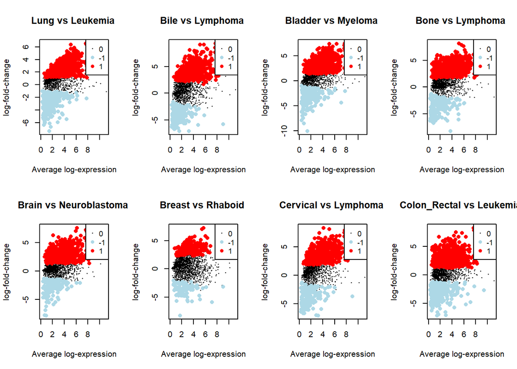

```r
par(mfrow = c(2, 4))
plotMD(fit.treat_ML,coef=11,status=res.treat_ML[,"LunLeuk"], values = c(-1, 1), hl.col=c("lightblue","red"), main = 'Lung vs Leukemia ')
plotMD(fit.treat_ML,coef=39,status=res.treat_ML[,"BileLym"], values = c(-1, 1), hl.col=c("lightblue","red"), main = 'Bile vs Lymphoma ')
plotMD(fit.treat_ML,coef=62,status=res.treat_ML[,"BladMyel"], values = c(-1, 1), hl.col=c("lightblue","red"), main = 'Bladder vs Myeloma ')
plotMD(fit.treat_ML,coef=82,status=res.treat_ML[,"BoneLymp"], values = c(-1, 1), hl.col=c("lightblue","red"), main = 'Bone vs Lymphoma ')
plotMD(fit.treat_ML,coef=104,status=res.treat_ML[,"BrainNeuro"], values = c(-1, 1), hl.col=c("lightblue","red"), main = 'Brain vs Neuroblastoma ')
plotMD(fit.treat_ML,coef=122,status=res.treat_ML[,"BreastRhab"], values = c(-1, 1), hl.col=c("lightblue","red"), main = 'Breast vs Rhaboid ')
plotMD(fit.treat_ML,coef=135,status=res.treat_ML[,"CervLym"], values = c(-1, 1), hl.col=c("lightblue","red"), main = 'Cervical vs Lymphoma ')
plotMD(fit.treat_ML,coef=150,status=res.treat_ML[,"ColonLeuk"], values = c(-1, 1), hl.col=c("lightblue","red"), main = 'Colon_Rectal vs Leukemia ')
```

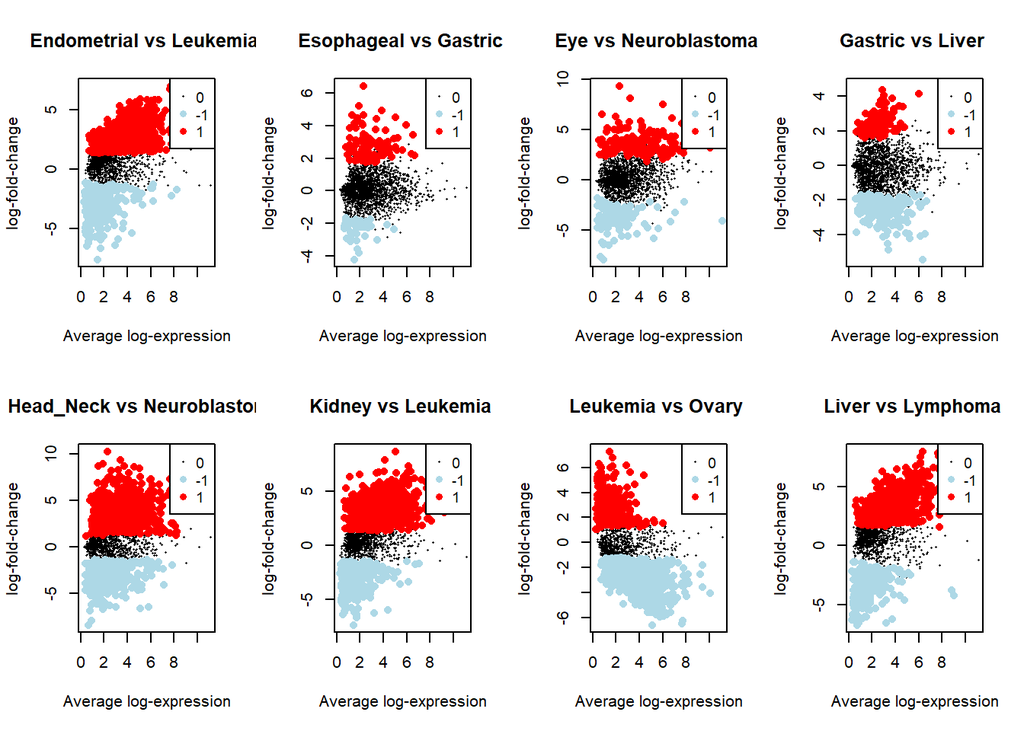

```r
plotMD(fit.treat_ML,coef=166,status=res.treat_ML[,"EndoLeuk"], values = c(-1, 1), hl.col=c("lightblue","red"), main = 'Endometrial vs Leukemia ')
plotMD(fit.treat_ML,coef=178,status=res.treat_ML[,"EsophGast"], values = c(-1, 1), hl.col=c("lightblue","red"), main = 'Esophageal vs Gastric ')
plotMD(fit.treat_ML,coef=199,status=res.treat_ML[,"EyeNeur"], values = c(-1, 1), hl.col=c("lightblue","red"), main = 'Eye vs Neuroblastoma ')
plotMD(fit.treat_ML,coef=209,status=res.treat_ML[,"GastLiver"], values = c(-1, 1), hl.col=c("lightblue","red"), main = 'Gastric vs Liver ')
plotMD(fit.treat_ML,coef=224,status=res.treat_ML[,"HeadNeur"], values = c(-1, 1), hl.col=c("lightblue","red"), main = 'Head_Neck vs Neuroblastoma ')
plotMD(fit.treat_ML,coef=231,status=res.treat_ML[,"KidLeuk"], values = c(-1, 1), hl.col=c("lightblue","red"), main = 'Kidney vs Leukemia ')
plotMD(fit.treat_ML,coef=246,status=res.treat_ML[,"LeukOvar"], values = c(-1, 1), hl.col=c("lightblue","red"), main = 'Leukemia vs Ovary ')
plotMD(fit.treat_ML,coef=252,status=res.treat_ML[,"LiverLym"], values = c(-1, 1), hl.col=c("lightblue","red"), main = 'Liver vs Lymphoma ')
```

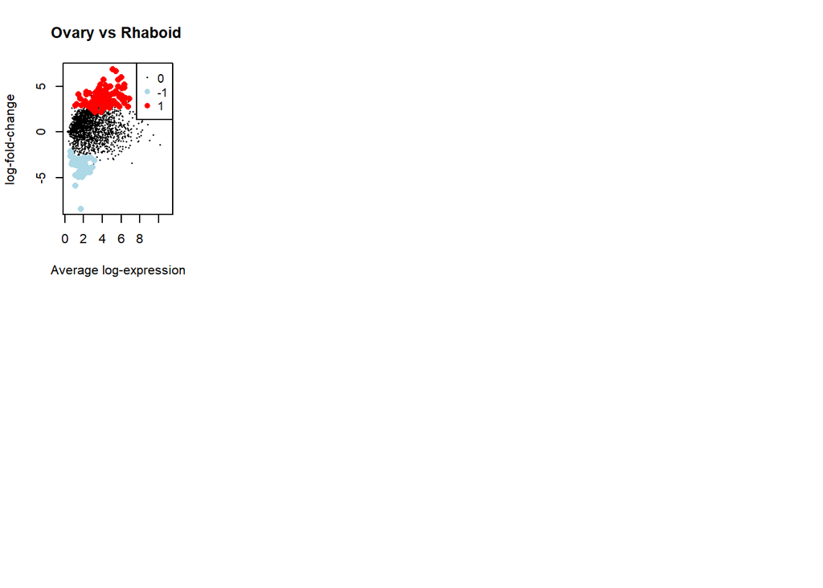

```r
plotMD(fit.treat_ML,coef=283,status=res.treat_ML[,"OvarRhab"], values = c(-1, 1), hl.col=c("lightblue","red"), main = 'Ovary vs Rhaboid ')
```

Com os resultados pretende-se obter os genes que estão mais frequentemente *over expressed* para as várias comparações no mesmo tecido em comparação. Para os vários tecidos existe um espetro alargado no número de genes que estão *up* ou *downregulated*, verificando que a tendências verificadas no heatmap se mantém, ou seja, cancro de Linfoma, Leucemia e Neuroblastoma.

### 5.3.4 Análise de enriquecimento

Para o enriquecimento foram selecionados para cada tecido os 10 genes *overexpressed* que surgiam mais vezes na totalidade de comparações de cada tecido.

**Tecido Pulmonar** Para o cancro **Pulmonar** estavam principalmente sobre *overexpressed* genes responsáveis por processos como **crescimento de tecido**, **mediação de macromoléculas**, **manutenção da estrutura celular** e **resposta ao sistema imunitário**.

**Tecido do Ducto Biliar** No cancro do **ducto biliar** foram encontrados *overexpressed* genes associados a um **desenvolvimento de estruturas anatómicas, tais como acrossomas ou carpelos** , **aumento da taxa de comunicação celular** e **atividade de transformação do genoma nuclear**.

**Tecido da bexiga** No cancro da **bexiga** foram encontrados *overexpressed* genes associados a um **aumento a taxa de processos catabólicos e anabólicos**, **aumento de catabolismo para obtenção de energia** , **expansão e multiplicação celular, favorecendo a interação entre diferentes estruturas**.

**Tecido cerebral** No cancro da **cérebro** foram encontrados genes *overexpressed* associados a um **aumento de processos de catabolismo e/ou anabolismo** , **conversão entre múltiplos metabolitos** , **combinação entre sinais extra e intercelulares** , **geração de estruturas anatómicas celulares** e **pela interação com a corrente sanguínea**.

**Tecido ósseo** No cancro **ósseo** foram encontrados genes *overexpressed* associados a **processos responsáveis pela locomoção celular** , **aumento da taxa metabólica** , **formação de células neuronais** e **controlo e modificação de metabolitos** e **à resposta imunitária a Leucócitos**.

**Tecido Mamário** No cancro **mamário** foram encontrados genes *overexpressed* associados à **maturação celular**, **desenvolvimento embrional** e **transferência de metabolitos**.

**Tecido Cervical** No cancro **cervical** foram encontrados genes *overexpressed* associados ao **aumento da atividade da kinase**, **aumento da frequência do ciclo miótico**, **formação de organelos** e **catalise de ligações peptídicas**.

**Tecido do colon** No cancro do **colon** foram encontrados genes *overexpressed* associados a **acelerar o processo de maturação celular e replicação** e **interação entre várias células**.

**Tecido uterino** No cancro do **útero** foram encontrados genes *overexpressed* associados a **diminuição da taxa de organelos e metabolitos**, **respostas imunitárias**, **desenvolvimento epitelial** e **catabolização proteica**.

**Tecido Esofágico** No cancro **esofágico** foram encontrados genes *overexpressed* associados ao **aumento da taxa de metabolização**, **crecimento celular** e **desenvolvimento celular**.

**Tecido ocular** No cancro **ocular** foram encontrados genes *overexpressed* associados ao **movimentação de organelos e metabolitos**, **movimento celular** e **desenvolvimento celular**.

**Tecido estomacal** No cancro **estomacal** foram encontrados genes *overexpressed* associados ao **desenvolvimento e maturação celular**, **movimento celular**, **transferência de grupos fosfato e álcool** e **aumento de formação de organelos**.

**Tecido facial** No cancro **facial** foram encontrados genes *overexpressed* associados ao **transporte de proteínas**, **atividade recetorial**, **ligação de cromatina** e **processos de manutenção celular**.

**Tecido renal** No cancro **renal** foram encontrados genes *overexpressed* associados ao **aumento de sinalização tranductional**, **degradação de carbonos** , **multiplicação e reprodução celular** e **hidrolise de ligações peptídicas**.

**Leucemia** Para a **leucemia** foram encontrados genes *overexpressed* associados ao **movimento intra-celular de iões, catiões …** , **alteração do gene mitocondrial** , **progressão de fases mitóticas** e **ligações proteicas**.

**Tecido do fígado** No cancro do **fígado** foram encontrados genes *overexpressed* associados à **modelação do sistema imunitário**, **degradação de terpenoids**, **regulação de radicais livres** e **degradação de moléculas de carbono**.

**Tecido linfático** No cancro do **linfático** foram encontrados genes *overexpressed* associados ao **transporte de catiões**, **desenvolvimento de musculo esquelético**, **formação de constituintes da matriz extracelular** e **formação de fosfolípidos**.

**Mieloma** No **mieloma** foram encontrados genes *overexpressed* associados a **movimento de moléculas e átomos**, **transporte de protões** e **transporte e alteração mitocondrial**.

**NeuroBlastoma** No **neuroblastoma** foram encontrados genes *overexpressed* associados a **modelação celular**, **processo de formação de complexos proteicos** e **alteração membranal**.

**Tecido Ovárico** No cancro do **ovário** foram encontrados genes *overexpressed* associados a **morte celular**, **junção de macromoléculas de modo a alteração celular**, **controlo da GTPase**e **agregação celular**.

```r
#Enriquecimento segunda matriz de contraste
tabLung = data.frame()
for (i in 1:24){
GOLung = goana(fit.treat_ML, coef=colnames(summary(res.treat_ML))[i],species = "Hs", geneid=fit.treat_ML$genes)
LungTAB = topGO(GOLung, n=10, sort = 'up')
tabLung = rbind(tabLung,LungTAB)
tabLung = tabLung[!duplicated(tabLung$Term) & tabLung$Ont != 'CC' ,]
tabLung = tabLung[order(tabLung$N, decreasing = TRUE),]
}
EnrLung = tabLung[1:10,]


tabBile = data.frame()
for (i in 25:47){
GOBile = goana(fit.treat_ML, coef=colnames(summary(res.treat_ML))[i],species = "Hs", geneid=fit.treat_ML$genes)
BileTAB = topGO(GOBile, n=10, sort = 'up')
tabBile = rbind(tabBile,BileTAB)
tabBile = tabBile[!duplicated(tabBile$Term) & tabBile$Ont != 'CC',]
tabBile = tabBile[order(tabBile$N, decreasing = TRUE),]
}
```

```
## No DE genes
## No DE genes
## No DE genes
```

```r
EnrBile = tabBile[1:10,]

tabBlad = data.frame()
for (i in 48:69){
GOBlad = goana(fit.treat_ML, coef=colnames(summary(res.treat_ML))[i],species = "Hs", geneid=fit.treat_ML$genes)
BladTAB = topGO(GOBlad, n=10, sort = 'up')
tabBlad = rbind(tabBlad,BladTAB)
tabBlad = tabBlad[!duplicated(tabBlad$Term) & tabBlad$Ont != 'CC',]
tabBlad = tabBlad[order(tabBlad$N, decreasing = TRUE),]
}
EnrBlad = tabBlad[1:10,]

tabBone = data.frame()
for (i in 70:90){
GOBone= goana(fit.treat_ML, coef=colnames(summary(res.treat_ML))[i],species = "Hs", geneid=fit.treat_ML$genes)
BoneTAB = topGO(GOBone, n=10, sort = 'up')
tabBone = rbind(tabBone,BoneTAB)
tabBone = tabBone[!duplicated(tabBone$Term) & tabBone$Ont != 'CC',]
tabBone = tabBone[order(tabBone$N, decreasing = TRUE),]
}
EnrBone = tabBone[1:10,]

tabBrain = data.frame()
for (i in 91:110){
GOBrain= goana(fit.treat_ML, coef=colnames(summary(res.treat_ML))[i],species = "Hs", geneid=fit.treat_ML$genes)
BrainTAB = topGO(GOBrain, n=10, sort = 'up')
tabBrain = rbind(tabBrain,BrainTAB)
tabBrain = tabBrain[!duplicated(tabBrain$Term) & tabBrain$Ont != 'CC',]
tabBrain = tabBrain[order(tabBrain$N, decreasing = TRUE),]
}
EnrBrain = tabBrain[1:10,]

tabBreast = data.frame()
for (i in 111:125){
GOBreast= goana(fit.treat_ML, coef=colnames(summary(res.treat_ML))[i],species = "Hs", geneid=fit.treat_ML$genes)
BreastTAB = topGO(GOBreast, n=10, sort = 'up')
tabBreast = rbind(tabBreast,BreastTAB)
tabBreast = tabBreast[!duplicated(tabBreast$Term) & tabBreast$Ont != 'CC',]
tabBreast = tabBreast[order(tabBreast$N, decreasing = TRUE),]
}
EnrBreast = tabBreast[1:10,]


tabCerv = data.frame()
for (i in 126:143){
GOCerv= goana(fit.treat_ML, coef=colnames(summary(res.treat_ML))[i],species = "Hs", geneid=fit.treat_ML$genes)
CervTAB = topGO(GOCerv, n=10, sort = 'up')
tabCerv = rbind(tabCerv,CervTAB)
tabCerv = tabCerv[!duplicated(tabCerv$Term) & tabCerv$Ont != 'CC',]
tabCerv = tabCerv[order(tabCerv$N, decreasing = TRUE),]
}
```

```
## No DE genes
```

```r
EnrCerv = tabCerv[1:10,]

tabColon = data.frame()
for (i in 144:160){
GOColon= goana(fit.treat_ML, coef=colnames(summary(res.treat_ML))[i],species = "Hs", geneid=fit.treat_ML$genes)
ColonTAB = topGO(GOColon, n=10, sort = 'up')
tabColon = rbind(tabColon,ColonTAB)
tabColon = tabColon[!duplicated(tabColon$Term) & tabColon$Ont != 'CC',]
tabColon = tabColon[order(tabColon$N, decreasing = TRUE),]
}
EnrColon = tabColon[1:10,]

tabEndo = data.frame()
for (i in 161:176){
GOEndo= goana(fit.treat_ML, coef=colnames(summary(res.treat_ML))[i],species = "Hs", geneid=fit.treat_ML$genes)
EndoTAB = topGO(GOEndo, n=10, sort = 'up')
tabEndo= rbind(tabEndo,EndoTAB)
tabEndo = tabEndo[!duplicated(tabEndo$Term) & tabEndo$Ont != 'CC',]
tabEndo = tabEndo[order(tabEndo$N, decreasing = TRUE),]
}
EnrEndo = tabEndo[1:10,]

tabEso = data.frame()
for (i in 177:191){
GOEso= goana(fit.treat_ML, coef=colnames(summary(res.treat_ML))[i],species = "Hs", geneid=fit.treat_ML$genes)
EsoTAB = topGO(GOEso, n=10, sort = 'up')
tabEso= rbind(tabEso,EsoTAB)
tabEso = tabEso[!duplicated(tabEso$Term) & tabEso$Ont != 'CC',]
tabEso = tabEso[order(tabEso$N, decreasing = TRUE),]
}
EnrEso = tabEso[1:10,]


tabEye = data.frame()
for (i in 192:205){
GOEye= goana(fit.treat_ML, coef=colnames(summary(res.treat_ML))[i],species = "Hs", geneid=fit.treat_ML$genes)
EyeTAB = topGO(GOEye, n=10, sort = 'up')
tabEye= rbind(tabEye,EyeTAB)
tabEye = tabEye[!duplicated(tabEye$Term) & tabEye$Ont != 'CC',]
tabEye = tabEye[order(tabEye$N, decreasing = TRUE),]
}
EnrEye = tabEye[1:10,]

tabGast = data.frame()
for (i in 206:218){
GOGast= goana(fit.treat_ML, coef=colnames(summary(res.treat_ML))[i],species = "Hs", geneid=fit.treat_ML$genes)
GastTAB = topGO(GOGast, n=10, sort = 'up')
tabGast= rbind(tabGast,GastTAB)
tabGast = tabGast[!duplicated(tabGast$Term) & tabGast$Ont != 'CC',]
tabGast = tabGast[order(tabGast$N, decreasing = TRUE),]
}
EnrGast = tabGast[1:10,]

tabHead = data.frame()
for (i in 219:230){
GOHead= goana(fit.treat_ML, coef=colnames(summary(res.treat_ML))[i],species = "Hs", geneid=fit.treat_ML$genes)
HeadTAB = topGO(GOHead, n=10, sort = 'up')
tabHead= rbind(tabHead,HeadTAB)
tabHead = tabHead[!duplicated(tabHead$Term) & tabHead$Ont != 'CC',]
tabHead = tabHead[order(tabHead$N, decreasing = TRUE),]
}
EnrHead = tabHead[1:10,]


tabKid = data.frame()
for (i in 231:241){
GOKid= goana(fit.treat_ML, coef=colnames(summary(res.treat_ML))[i],species = "Hs", geneid=fit.treat_ML$genes)
KidTAB = topGO(GOKid, n=10, sort = 'up')
tabKid= rbind(tabKid,KidTAB)
tabKid = tabKid[!duplicated(tabKid$Term) & tabKid$Ont != 'CC',]
tabKid = tabKid[order(tabKid$N, decreasing = TRUE),]
}
EnrKid = tabKid[1:10,]


tabLeu = data.frame()
for (i in 242:251){
GOLeu= goana(fit.treat_ML, coef=colnames(summary(res.treat_ML))[i],species = "Hs", geneid=fit.treat_ML$genes)
LeuTAB = topGO(GOLeu, n=10, sort = 'up')
tabLeu= rbind(tabLeu,LeuTAB)
tabLeu = tabLeu[!duplicated(tabLeu$Term) & tabLeu$Ont != 'CC',]
tabLeu = tabLeu[order(tabLeu$N, decreasing = TRUE),]
}
EnrLeu = tabLeu[1:10,]

tabLiv = data.frame()
for (i in 252:260){
GOLiv= goana(fit.treat_ML, coef=colnames(summary(res.treat_ML))[i],species = "Hs", geneid=fit.treat_ML$genes)
LivTAB = topGO(GOLiv, n=10, sort = 'up')
tabLiv= rbind(tabLiv,LivTAB)
tabLiv = tabLiv[!duplicated(tabLiv$Term) & tabLiv$Ont != 'CC',]
tabLiv = tabLiv[order(tabLiv$N, decreasing = TRUE),]
}
EnrLiv = tabLiv[1:10,]

tabLym = data.frame()
for (i in 261:268){
GOLym= goana(fit.treat_ML, coef=colnames(summary(res.treat_ML))[i],species = "Hs", geneid=fit.treat_ML$genes)
LymTAB = topGO(GOLym, n=10, sort = 'up')
tabLym= rbind(tabLym,LymTAB)
tabLym = tabLym[!duplicated(tabLym$Term) & tabLym$Ont != 'CC',]
tabLym = tabLym[order(tabLym$N, decreasing = TRUE),]
}
EnrLym = tabLym[1:10,]


tabMye = data.frame()
for (i in 269:275){
GOMye= goana(fit.treat_ML, coef=colnames(summary(res.treat_ML))[i],species = "Hs", geneid=fit.treat_ML$genes)
MyeTAB = topGO(GOMye, n=10, sort = 'up')
tabMye= rbind(tabMye,MyeTAB)
tabMye = tabMye[!duplicated(tabMye$Term) & tabMye$Ont != 'CC',]
tabMye = tabMye[order(tabMye$N, decreasing = TRUE),]
}
EnrMye = tabMye[1:10,]


tabNeur = data.frame()
for (i in 276:281){
GONeur= goana(fit.treat_ML, coef=colnames(summary(res.treat_ML))[i],species = "Hs", geneid=fit.treat_ML$genes)
NeurTAB = topGO(GONeur, n=10, sort = 'up')
tabNeur= rbind(tabNeur,NeurTAB)
tabNeur = tabNeur[!duplicated(tabNeur$Term) & tabNeur$Ont != 'CC',]
tabNeur = tabNeur[order(tabNeur$N, decreasing = TRUE),]
}
EnrNeur = tabNeur[1:10,]

tabOvar = data.frame()
for (i in 282:286){
GOOvar= goana(fit.treat_ML, coef=colnames(summary(res.treat_ML))[i],species = "Hs", geneid=fit.treat_ML$genes)
OvarTAB = topGO(GOOvar, n=10, sort = 'up')
tabOvar= rbind(tabOvar,OvarTAB)
tabOvar = tabOvar[!duplicated(tabOvar$Term) & tabOvar$Ont != 'CC',]
tabOvar = tabOvar[order(tabOvar$N, decreasing = TRUE),]
}
EnrOvar = tabOvar[1:10,]

tabPanc = data.frame()
for (i in 287:290){
GOPanc= goana(fit.treat_ML, coef=colnames(summary(res.treat_ML))[i],species = "Hs", geneid=fit.treat_ML$genes)
PancTAB = topGO(GOPanc, n=10, sort = 'up')
tabPanc= rbind(tabPanc,PancTAB)
tabPanc = tabPanc[!duplicated(tabPanc$Term) & tabPanc$Ont != 'CC',]
tabPanc = tabPanc[order(tabPanc$N, decreasing = TRUE),]
}
EnrPanc = tabPanc[1:10,]


tabRhab = data.frame()
for (i in 291:293){
GORhab= goana(fit.treat_ML, coef=colnames(summary(res.treat_ML))[i],species = "Hs", geneid=fit.treat_ML$genes)
RhabTAB = topGO(GORhab, n=10, sort = 'up')
tabRhab= rbind(tabRhab,RhabTAB)
tabRhab = tabRhab[!duplicated(tabRhab$Term) & tabRhab$Ont != 'CC',]
tabRhab = tabRhab[order(tabRhab$N, decreasing = TRUE),]
}
EnrRhab = tabRhab[1:10,]

tabSarc = data.frame()
for (i in 294:295){
GOSarc= goana(fit.treat_ML, coef=colnames(summary(res.treat_ML))[i],species = "Hs", geneid=fit.treat_ML$genes)
SarcTAB = topGO(GOSarc, n=10, sort = 'up')
tabSarc= rbind(tabSarc,SarcTAB)
tabSarc = tabSarc[!duplicated(tabSarc$Term)& tabSarc$Ont != 'CC',]
tabSarc = tabSarc[order(tabSarc$N, decreasing = TRUE),]
}
EnrSarc = tabSarc[1:10,]

GOSkin= goana(fit.treat_ML, coef=colnames(summary(res.treat_ML))[296],species = "Hs", geneid=fit.treat_ML$genes)
tabSkin = topGO(GOSkin, n=10, sort = 'up')
```

# 6 Machine Learning

## 6.1 PCA

```r
#Filtração dos genes pelos UP-regulated obtidos na segunda matriz de contraste
#Obtenção da do dataset de expression com todos os genes UP-Regulated
genename = c()
FDR = 0.05
for (i in 1:296){
  coef = colnames(summary(res.treat_ML))[i]
  fdr.coef <- p.adjust(fit.treat_ML$p.value[,coef], method = "BH")
  UP = fdr.coef[fdr.coef < FDR & fit.treat_ML$coefficients[,coef] > 0]
  UP = sort(UP,decreasing = TRUE)[1:5]
  genename = append(genename, names(UP))
}
genename = genename[!duplicated(genename)]

Sub_CCLE_expression_UP = Sub_CCLE_expression1[,intersect(colnames(Sub_CCLE_expression1),genename)]
CopyNumber_UP = CopyNumber[,intersect(colnames(CopyNumber),genename)]
Crispr_UP = Crispr[,intersect(colnames(Crispr),genename)]

#Filtração do dataset  Expression com todos os genes UP-Regulated e com atividade cas-9 negativa ( mais essenciais)
Genes_Ca9 = c()
FDR = 0.05
for (i in 1:296){
  coef = colnames(summary(res.treat_ML))[i]
  nv = sapply(seq(from=1, to=nchar(coef), by=3), function(j) substr(coef, j, j+2))
  indexes = grep(nv[1], Sample_Info$primary_disease)
  fdr.coef <- p.adjust(fit.treat_ML$p.value[,coef], method = "BH")
  UP = fdr.coef[fdr.coef < FDR & fit.treat_ML$coefficients[,coef] > 0]
  cas = Crispr_UP[indexes,intersect(colnames(Crispr_UP),names(UP))]
  if (ncol(cas) != 0){
    for (j in 1:ncol(cas)){
      if (mean(cas[,j]) < 0){
        Genes_Ca9 = append(Genes_Ca9,colnames(cas)[j])
      }
    }
  }
}
Genes_Ca9 = Genes_Ca9[!duplicated(Genes_Ca9)]
Sub_CCLE_Expression_Cas9 = Sub_CCLE_expression_UP[, intersect(colnames(Sub_CCLE_expression_UP),Genes_Ca9)]

#Filtração do dataset  Expression com todos os genes UP-Regulated e com atividade cas-9 negativa ( mais essenciais)
Genes_Copy = c()
FDR = 0.05
for (i in 1:296){
  coef = colnames(summary(res.treat_ML))[i]
  nv = sapply(seq(from=1, to=nchar(coef), by=3), function(j) substr(coef, j, j+2))
  indexes = grep(nv[1], Sample_Info$primary_disease)
  fdr.coef <- p.adjust(fit.treat_ML$p.value[,coef], method = "BH")
  UP = fdr.coef[fdr.coef < FDR & fit.treat_ML$coefficients[,coef] > 0]
  copy = CopyNumber_UP[indexes,intersect(colnames(CopyNumber_UP),names(UP))]
  if (ncol(copy) != 0){
    for (j in 1:ncol(copy)){
      if (mean(copy[,j]) >= 1.1){
        Genes_Copy = append(Genes_Copy,colnames(copy)[j])
      }
    }
  }
}
Genes_Copy = Genes_Copy[!duplicated(Genes_Copy)]
Sub_CCLE_Expression_Copy = Sub_CCLE_expression_UP[, intersect(colnames(Sub_CCLE_expression_UP),Genes_Copy)]
```

```r
### Associação quais os essenciais

#Expression
pcaexp = prcomp(Sub_CCLE_expression_UP)
summary(pcaexp)
```

```
## Importance of components:
##                            PC1     PC2      PC3      PC4     PC5     PC6
## Standard deviation     26.1264 20.7387 13.44328 11.65830 10.5396 9.39014
## Proportion of Variance  0.1727  0.1088  0.04572  0.03438  0.0281 0.02231
## Cumulative Proportion   0.1727  0.2815  0.32721  0.36160  0.3897 0.41201
##                            PC7     PC8     PC9    PC10    PC11    PC12    PC13
## Standard deviation     9.01629 8.62334 8.02165 7.87519 7.65186 6.61461 6.29450
## Proportion of Variance 0.02057 0.01881 0.01628 0.01569 0.01481 0.01107 0.01002
## Cumulative Proportion  0.43257 0.45139 0.46767 0.48336 0.49817 0.50924 0.51926
##                           PC14   PC15    PC16    PC17    PC18    PC19    PC20
## Standard deviation     6.15245 6.0630 5.92330 5.59617 5.47660 5.18100 5.11035
## Proportion of Variance 0.00958 0.0093 0.00888 0.00792 0.00759 0.00679 0.00661
## Cumulative Proportion  0.52884 0.5381 0.54701 0.55494 0.56252 0.56931 0.57592
##                           PC21    PC22    PC23    PC24    PC25    PC26    PC27
## Standard deviation     5.02561 4.82128 4.73572 4.63123 4.55869 4.49718 4.40469
## Proportion of Variance 0.00639 0.00588 0.00567 0.00543 0.00526 0.00512 0.00491
## Cumulative Proportion  0.58231 0.58819 0.59387 0.59929 0.60455 0.60967 0.61457
##                           PC28    PC29    PC30    PC31    PC32    PC33    PC34
## Standard deviation     4.35191 4.34610 4.27667 4.10637 4.04902 4.03178 3.99603
## Proportion of Variance 0.00479 0.00478 0.00463 0.00427 0.00415 0.00411 0.00404
## Cumulative Proportion  0.61936 0.62414 0.62877 0.63304 0.63718 0.64130 0.64534
##                           PC35    PC36    PC37    PC38    PC39    PC40    PC41
## Standard deviation     3.96951 3.91409 3.86684 3.82764 3.72547 3.71160 3.65091
## Proportion of Variance 0.00399 0.00388 0.00378 0.00371 0.00351 0.00349 0.00337
## Cumulative Proportion  0.64932 0.65320 0.65698 0.66069 0.66420 0.66768 0.67106
##                           PC42    PC43    PC44    PC45    PC46    PC47    PC48
## Standard deviation     3.60302 3.51812 3.48453 3.42217 3.41107 3.40097 3.35811
## Proportion of Variance 0.00328 0.00313 0.00307 0.00296 0.00294 0.00293 0.00285
## Cumulative Proportion  0.67434 0.67747 0.68054 0.68351 0.68645 0.68938 0.69223
##                           PC49    PC50    PC51    PC52    PC53    PC54    PC55
## Standard deviation     3.32191 3.31285 3.28559 3.26327 3.22746 3.18835 3.16243
## Proportion of Variance 0.00279 0.00278 0.00273 0.00269 0.00264 0.00257 0.00253
## Cumulative Proportion  0.69502 0.69780 0.70053 0.70322 0.70586 0.70843 0.71096
##                          PC56    PC57    PC58    PC59    PC60    PC61    PC62
## Standard deviation     3.1450 3.10423 3.08984 3.07146 3.04512 3.03079 3.00696
## Proportion of Variance 0.0025 0.00244 0.00242 0.00239 0.00235 0.00232 0.00229
## Cumulative Proportion  0.7135 0.71590 0.71831 0.72070 0.72305 0.72537 0.72766
##                           PC63    PC64    PC65    PC66    PC67   PC68    PC69
## Standard deviation     2.98807 2.97590 2.94531 2.91888 2.88492 2.8832 2.86747
## Proportion of Variance 0.00226 0.00224 0.00219 0.00216 0.00211 0.0021 0.00208
```

[output cut: 290 more lines]

```
## Standard deviation     0.35807 0.35346 0.34900 0.34681 0.34394 0.33886 0.33378
## Proportion of Variance 0.00003 0.00003 0.00003 0.00003 0.00003 0.00003 0.00003
## Cumulative Proportion  0.99945 0.99948 0.99951 0.99954 0.99957 0.99960 0.99963
##                          PC582   PC583   PC584   PC585   PC586   PC587   PC588
## Standard deviation     0.33249 0.33145 0.32258 0.32150 0.31795 0.31006 0.30857
## Proportion of Variance 0.00003 0.00003 0.00003 0.00003 0.00003 0.00002 0.00002
## Cumulative Proportion  0.99966 0.99969 0.99971 0.99974 0.99976 0.99979 0.99981
##                          PC589   PC590   PC591   PC592   PC593   PC594   PC595
## Standard deviation     0.30573 0.30328 0.29917 0.29145 0.28633 0.28280 0.28207
## Proportion of Variance 0.00002 0.00002 0.00002 0.00002 0.00002 0.00002 0.00002
## Cumulative Proportion  0.99984 0.99986 0.99988 0.99990 0.99992 0.99994 0.99996
##                          PC596   PC597     PC598
## Standard deviation     0.26708 0.26287 4.431e-15
## Proportion of Variance 0.00002 0.00002 0.000e+00
## Cumulative Proportion  0.99998 1.00000 1.000e+00
```

```r
min(which(summary(pcaexp)$importance[3,]>0.9))
```

```
## [1] 201
```

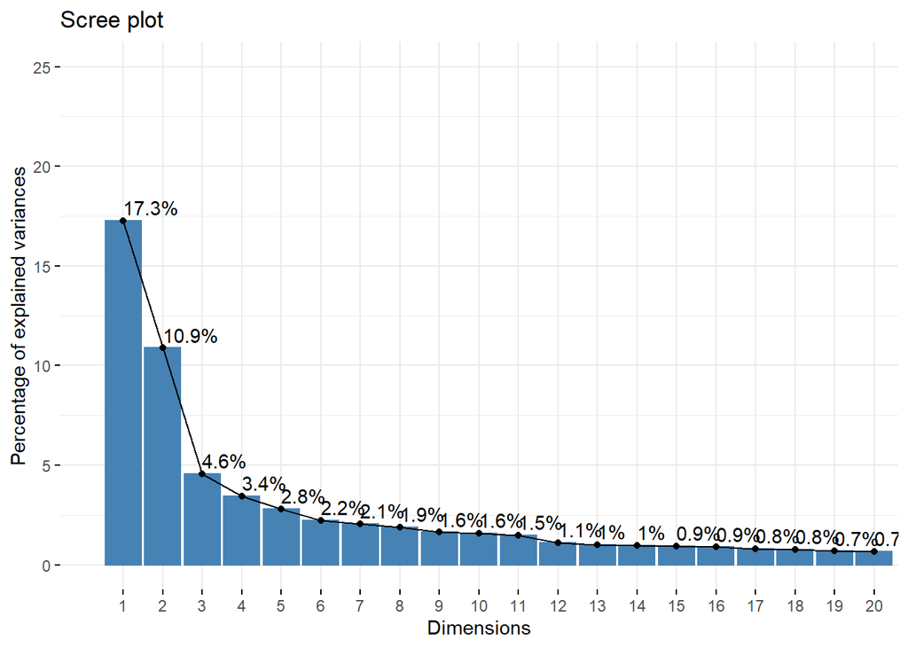

```r
eig.val <- get_eigenvalue(pcaexp)
fviz_eig(pcaexp, addlabels = TRUE, ylim = c(0, 25), xlim=c(0,20), ncp = 20)
```

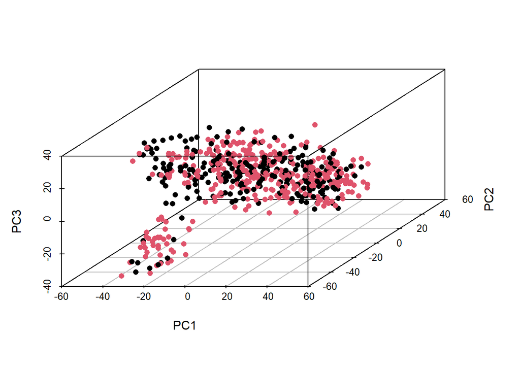

```r
scatterplot3d(pcaexp$x[,1:3], color = as.integer(as.factor(Sample_Info$primary_or_metastasis)), pch=16, xlab="PC1", ylab = "PC2")
```

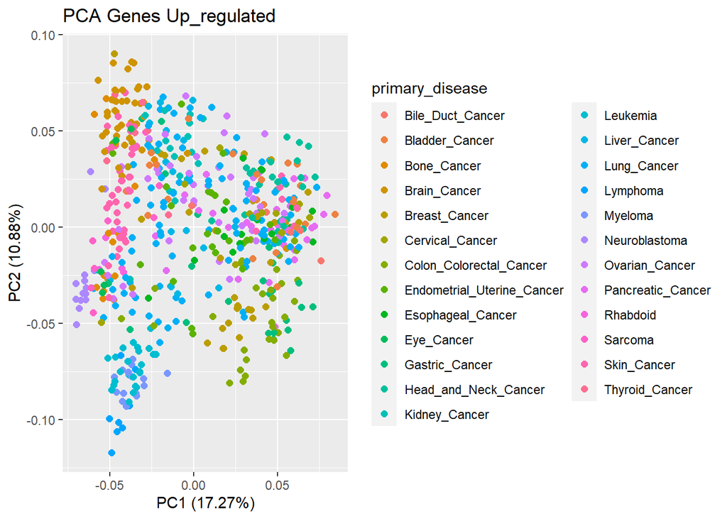

```r
autoplot(pcaexp,
         data = as.data.frame(Sample_Info),
         colour="primary_disease",
         size=2,
         main = "PCA Genes Up_regulated")
```

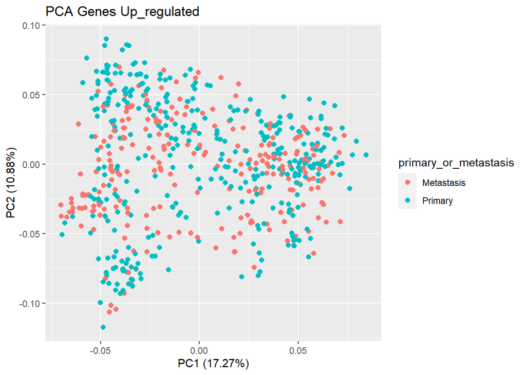

```r
autoplot(pcaexp,
         data = as.data.frame(Sample_Info),
         colour="primary_or_metastasis",
         size=2,
         main = "PCA Genes Up_regulated")
```

```r
#CopyNumber
pcagene = prcomp(Sub_CCLE_Expression_Copy)
summary(pcagene)
```

```
## Importance of components:
##                            PC1     PC2    PC3    PC4     PC5     PC6     PC7
## Standard deviation     19.9783 16.0162 9.7017 9.0685 7.52843 6.86124 6.70703
## Proportion of Variance  0.1849  0.1188 0.0436 0.0381 0.02626 0.02181 0.02084
## Cumulative Proportion   0.1849  0.3037 0.3473 0.3854 0.41169 0.43350 0.45434
##                            PC8    PC9    PC10    PC11    PC12    PC13    PC14
## Standard deviation     6.48916 6.1295 5.74432 5.63164 4.94700 4.67346 4.63875
## Proportion of Variance 0.01951 0.0174 0.01529 0.01469 0.01134 0.01012 0.00997
## Cumulative Proportion  0.47384 0.4913 0.50654 0.52123 0.53256 0.54268 0.55265
##                           PC15    PC16    PC17    PC18    PC19    PC20   PC21
## Standard deviation     4.49521 4.46226 4.30447 3.98850 3.88576 3.78840 3.6865
## Proportion of Variance 0.00936 0.00922 0.00858 0.00737 0.00699 0.00665 0.0063
## Cumulative Proportion  0.56201 0.57124 0.57982 0.58719 0.59418 0.60083 0.6071
##                           PC22    PC23    PC24    PC25   PC26    PC27    PC28
## Standard deviation     3.66253 3.57347 3.52158 3.42385 3.4142 3.38649 3.31016
## Proportion of Variance 0.00621 0.00592 0.00575 0.00543 0.0054 0.00531 0.00508
## Cumulative Proportion  0.61334 0.61926 0.62500 0.63043 0.6358 0.64115 0.64622
##                           PC29    PC30    PC31    PC32    PC33    PC34    PC35
## Standard deviation     3.23853 3.21625 3.16189 3.14400 3.07923 3.07547 3.05367
## Proportion of Variance 0.00486 0.00479 0.00463 0.00458 0.00439 0.00438 0.00432
## Cumulative Proportion  0.65108 0.65587 0.66050 0.66508 0.66948 0.67386 0.67818
##                           PC36    PC37   PC38    PC39    PC40    PC41    PC42
## Standard deviation     3.03503 2.98835 2.9011 2.85376 2.83058 2.79263 2.75623
## Proportion of Variance 0.00427 0.00414 0.0039 0.00377 0.00371 0.00361 0.00352
## Cumulative Proportion  0.68244 0.68658 0.6905 0.69425 0.69796 0.70158 0.70510
##                           PC43    PC44    PC45    PC46    PC47    PC48    PC49
## Standard deviation     2.74011 2.68092 2.66063 2.63526 2.60607 2.59576 2.55833
## Proportion of Variance 0.00348 0.00333 0.00328 0.00322 0.00315 0.00312 0.00303
## Cumulative Proportion  0.70858 0.71190 0.71518 0.71840 0.72155 0.72467 0.72770
##                           PC50    PC51    PC52    PC53    PC54    PC55    PC56
## Standard deviation     2.53901 2.53102 2.49836 2.48752 2.47299 2.46328 2.43201
## Proportion of Variance 0.00299 0.00297 0.00289 0.00287 0.00283 0.00281 0.00274
## Cumulative Proportion  0.73069 0.73365 0.73655 0.73941 0.74225 0.74506 0.74780
##                           PC57    PC58    PC59    PC60    PC61    PC62    PC63
## Standard deviation     2.42130 2.40058 2.37969 2.36117 2.35578 2.30696 2.29560
## Proportion of Variance 0.00272 0.00267 0.00262 0.00258 0.00257 0.00247 0.00244
## Cumulative Proportion  0.75051 0.75318 0.75581 0.75839 0.76096 0.76343 0.76587
##                          PC64    PC65    PC66    PC67    PC68    PC69    PC70
## Standard deviation     2.2768 2.26193 2.24015 2.23116 2.22210 2.20799 2.19455
## Proportion of Variance 0.0024 0.00237 0.00232 0.00231 0.00229 0.00226 0.00223
```

[output cut: 242 more lines]

```
## Standard deviation     0.15515 0.15404 0.14965 0.14637 0.14183 0.13992 0.13736
## Proportion of Variance 0.00001 0.00001 0.00001 0.00001 0.00001 0.00001 0.00001
## Cumulative Proportion  0.99984 0.99985 0.99986 0.99987 0.99988 0.99989 0.99989
##                          PC498   PC499   PC500   PC501   PC502   PC503   PC504
## Standard deviation     0.13375 0.13170 0.12961 0.12600 0.12455 0.11804 0.11566
## Proportion of Variance 0.00001 0.00001 0.00001 0.00001 0.00001 0.00001 0.00001
## Cumulative Proportion  0.99990 0.99991 0.99992 0.99993 0.99993 0.99994 0.99995
##                          PC505   PC506   PC507   PC508 PC509   PC510   PC511
## Standard deviation     0.11440 0.10966 0.10828 0.10548 0.102 0.09931 0.09423
## Proportion of Variance 0.00001 0.00001 0.00001 0.00001 0.000 0.00000 0.00000
## Cumulative Proportion  0.99995 0.99996 0.99996 0.99997 1.000 0.99998 0.99998
##                         PC512   PC513   PC514   PC515  PC516  PC517
## Standard deviation     0.0901 0.08466 0.08406 0.08135 0.0774 0.0635
## Proportion of Variance 0.0000 0.00000 0.00000 0.00000 0.0000 0.0000
## Cumulative Proportion  1.0000 0.99999 0.99999 1.00000 1.0000 1.0000
```

```r
min(which(summary(pcagene)$importance[3,]>0.9))
```

```
## [1] 151
```

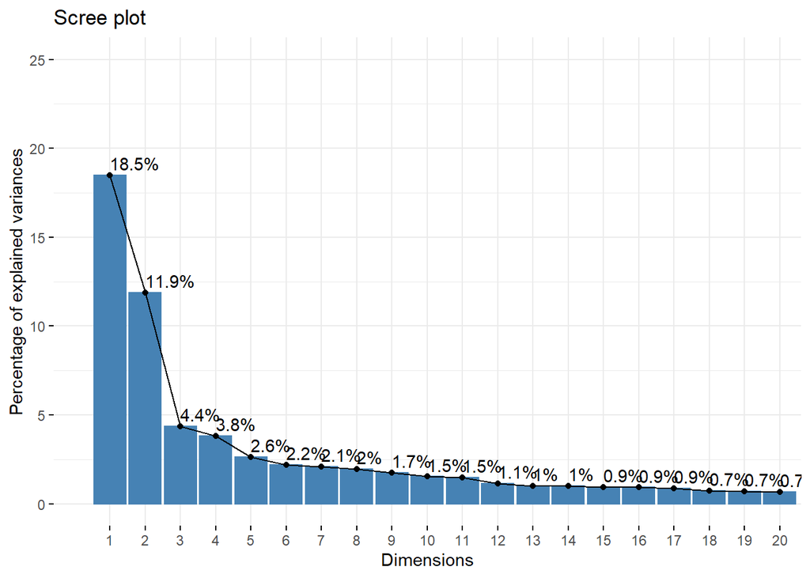

```r
eig.val <- get_eigenvalue(pcagene)
fviz_eig(pcagene, addlabels = TRUE, ylim = c(0, 25), xlim=c(0,20), ncp = 20)
```